# Análisis delito hurto a personas

En el siguiente procesamiento de los datos encontrará:

### Preprocesamiento

*Datasets de 2014 y 2015*

- Se renombra el título de los atributos como se encuntra en los dataset de 2016 y 2017.
- Se eliminan los registro de resumen por no corresponder a eventos de hurto.
- Se transforma a formato datetime para los atributos *Fecha* y *Hora*.

*Datasets de 2016 y 2017*

- Se transforma a formato datetime para los atributos *Fecha* y *Hora*.

### Filtrado

- Se concatenan los datasets de 2014, 2015, 2016 y 2017.
- Se filtran los datos obteniendo únicamente los de Bogotá.
- Se calcula la frecuencia de hurtos a personas por día.
- Se aplica el filtro Hodrick-Prescott para separar la tendencia y el componente ciclico de la serie.

### Resultado

- Se grafia la serie y la tendencia calculada.
- Se obtiene la información descriptiva de los datasets.

```python
import numpy as np
import pandas as pd
#import pandas.io.data as web
import pandas_profiling
import datetime as dt
#from pandas import Series, DataFrame, Panel
import re
import math
import seaborn as sns
import matplotlib.pyplot as plt
from pydataset import data
import statsmodels.api as sm
#import statsmodels
import os as os

# graficos incrustados
%matplotlib inline

# pandas solo 4 decimales
#pd.set_option('precision', 4)
```

```python
os.getcwd()
```

```
'/Users/jofremanchola/Jofre/uniandes/MINE/5VisualAnalytics/Tarea 3'
```

```python
%cd Hurto_a_personas
```

```
/Users/jofremanchola/Jofre/uniandes/MINE/5VisualAnalytics/Tarea 3/Hurto_a_personas
```

### Importando el dataset

```python
'''
hp2010=pd.read_csv("Hurto_Personas_2010.csv",sep=",",converters={'Fecha':pd.to_datetime});
hp2011=pd.read_csv("Hurto_Personas_2011.csv",sep=",",converters={'Fecha':pd.to_datetime});
hp2012=pd.read_csv("Hurto_Personas_2012.csv",sep=",",converters={'Fecha':pd.to_datetime});
hp2013=pd.read_csv("Hurto_Personas_2013.csv",sep=",",converters={'Fecha':pd.to_datetime});
'''
hp2014=pd.read_csv("Hurto_Personas_2014.csv",sep=",");
hp2015=pd.read_csv("Hurto_Personas_2015.csv",sep=",");
hp2016=pd.read_csv("Hurto_Personas_2016.csv",sep=",",converters={'Fecha':pd.to_datetime,'Hora':pd.to_datetime});
hp2017=pd.read_csv("Hurto_Personas_2017.csv",sep=",",converters={'Fecha':pd.to_datetime,'Hora':pd.to_datetime});
```

```python
#hp = pd.concat([hp2010,hp2011,hp2012,hp2013,hp2014,hp2015,hp2016,hp2017])
```

### Preprocesando

```python
hp2014 = hp2014.rename(index=str, columns={'FECHA': 'Fecha','DEPARTAMENTO ': 'Departamento','MUNICIPIO': 'Municipio','DIA ': 'Día','HORA': 'Hora','BARRIO': 'Barrio','ZONA': 'Zona','CLASE SITIO': 'Clase de sitio','ARMA EMPLEADA': 'Arma empleada','MOVIL AGRESOR': 'Móvil Agresor','MOVIL VICTIMA': 'Móvil Victima','EDAD': 'Edad','SEXO': 'Sexo','ESTADO CIVIL': 'Estado civil','PAIS NACE': 'País de nacimiento','CLASE EMPLEADO': 'Clase de empleado','PROFESION': 'Profesión','ESCOLARIDAD': 'Escolaridad','CODIGO DANE': 'Código DANE','2014': 'Cantidad'})
hp2014 = hp2014[hp2014.Fecha!='TOTAL']
hp2014['Fecha'] = pd.to_datetime(hp2014['Fecha'])
hp2014['Hora'] = pd.to_datetime(hp2014.Hora)
```

```python
hp2015 = hp2015.rename(index=str, columns={'FECHA': 'Fecha','DEPARTAMENTO': 'Departamento','MUNICIPIO': 'Municipio','DIA ': 'Día','HORA ': 'Hora','BARRIO': 'Barrio','ZONA': 'Zona','CLASE SITIO': 'Clase de sitio','ARMA EMPLEADA': 'Arma empleada','MOVIL AGRESOR': 'Móvil Agresor','MOVIL VICTIMA': 'Móvil Victima','EDAD': 'Edad','SEXO': 'Sexo','ESTADO CIVIL': 'Estado civil','PAIS NACE': 'País de nacimiento','CLASE EMPLEADO': 'Clase de empleado','PROFESION': 'Profesión','ESCOLARIDAD': 'Escolaridad','CODIGO DANE': 'Código DANE','2015': 'Cantidad'})
tam = hp2015.shape
hp2015 = hp2015[:tam[0]-2]
hp2015['Fecha'] = pd.to_datetime(hp2015['Fecha'])
hp2015['Hora'] = pd.to_datetime(hp2015.Hora)
```

### Filtrando

```python
# hp = pd.concat([hp2010,hp2011,hp2012,hp2013,hp2014,hp2015,hp2016,hp2017])
hp = pd.concat([hp2014,hp2015,hp2016,hp2017])
```

```python
hp = hp[hp.Municipio=='BOGOTÁ D.C. (CT)']
```

```python
hp.shape
```

```
(116424, 20)
```

```python
hp.Departamento.unique()
```

```
array(['CUNDINAMARCA'], dtype=object)
```

```python
hp.dtypes
```

```
Fecha                 datetime64[ns]
Departamento                  object
Municipio                     object
Día                           object
Hora                  datetime64[ns]
Barrio                        object
Zona                          object
Clase de sitio                object
Arma empleada                 object
Móvil Agresor                 object
Móvil Victima                 object
Edad                          object
Sexo                          object
Estado civil                  object
País de nacimiento            object
Clase de empleado             object
Profesión                     object
Escolaridad                   object
Código DANE                  float64
Cantidad                     float64
dtype: object
```

```python
#hp2017.Fecha=hp2017.Fecha.dt.date
#hp2017.Hora=hp2017.Hora.dt.time
```

```python
#dates = pd.date_range('2017-01', '2017-07', freq='M')
dates = pd.date_range('2016-01-01', '2017-07-31', freq='D')
dates
```

```
DatetimeIndex(['2016-01-01', '2016-01-02', '2016-01-03', '2016-01-04',
               '2016-01-05', '2016-01-06', '2016-01-07', '2016-01-08',
               '2016-01-09', '2016-01-10',
               ...
               '2017-07-22', '2017-07-23', '2017-07-24', '2017-07-25',
               '2017-07-26', '2017-07-27', '2017-07-28', '2017-07-29',
               '2017-07-30', '2017-07-31'],
              dtype='datetime64[ns]', length=578, freq='D')
```

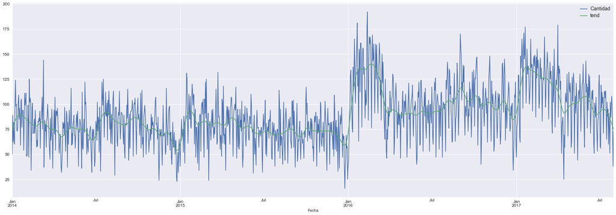

```python
hp_2 = hp.groupby(["Fecha"]).count()

# Aplicando el filtro Hodrick-Prescott para separar en tendencia y
# componente ciclico.
hp_ciclo, hp_tend = sm.tsa.filters.hpfilter(hp_2.Cantidad)

hp_2['tend'] = hp_tend
hp_2['ciclo'] = hp_ciclo
hp_2 = hp_2[['Cantidad','tend','ciclo']]

# graficando la variacion del precio real con la tendencia.
#hp_2[['Cantidad', 'tend', 'ciclo']].plot(figsize=(30, 10), fontsize=12);
hp_2[['Cantidad', 'tend']].plot(figsize=(30, 10), fontsize=12);
legend = plt.legend()
legend.prop.set_size(14)
```

Overview

Dataset info

| Number of variables | 20 |
| --- | --- |
| Number of observations | 80010 |
| Total Missing (%) | 0.0% |
| Total size in memory | 12.2 MiB |
| Average record size in memory | 160.0 B |

Variables types

| Numeric | 2 |
| --- | --- |
| Categorical | 16 |
| Date | 2 |
| Text (Unique) | 0 |
| Rejected | 0 |

Warnings

- `Barrio` has a high cardinality: 9812 distinct values Warning

- `Cantidad` is highly skewed (γ1 = 30.201)

- `Clase de sitio` has a high cardinality: 333 distinct values Warning

- `Edad` has a high cardinality: 96 distinct values Warning

- `Municipio` has a high cardinality: 774 distinct values Warning

- `País de nacimiento` has a high cardinality: 72 distinct values Warning

- `Profesión` has a high cardinality: 109 distinct values Warning

Variables

Arma empleada  
Categorical

| Distinct count | 11 |
| --- | --- |
| Unique (%) | 0.0% |
| Missing (%) | 0.0% |
| Missing (n) | 0 |

| SIN EMPLEO DE ARMAS | 36491 |
| --- | --- |
| ARMA BLANCA / CORTOPUNZANTE | 18634 |
| ARMA DE FUEGO | 15920 |
| Other values (8) | 8965 |

Toggle details

| Value | Count | Frequency (%) |  |
| --- | --- | --- | --- |
| SIN EMPLEO DE ARMAS | 36491 | 45.6% |  |
| ARMA BLANCA / CORTOPUNZANTE | 18634 | 23.3% |  |
| ARMA DE FUEGO | 15920 | 19.9% |  |
| CONTUNDENTES | 8127 | 10.2% |  |
| ESCOPOLAMINA | 808 | 1.0% |  |
| PERRO | 16 | 0.0% |  |
| - | 6 | 0.0% |  |
| JERINGA | 4 | 0.0% |  |
| CORTANTES | 2 | 0.0% |  |
| LLAVE MAESTRA | 1 | 0.0% |  |

Barrio  
Categorical

| Distinct count | 9812 |
| --- | --- |
| Unique (%) | 12.3% |
| Missing (%) | 0.0% |
| Missing (n) | 0 |

| CENTRO | 3828 |
| --- | --- |
| BELLA SUIZA E-1 | 2457 |
| LA CANDELARIA C-10 | 1192 |
| Other values (9809) | 72533 |

Toggle details

| Value | Count | Frequency (%) |  |
| --- | --- | --- | --- |
| CENTRO | 3828 | 4.8% |  |
| BELLA SUIZA E-1 | 2457 | 3.1% |  |
| LA CANDELARIA C-10 | 1192 | 1.5% |  |
| EL CENTRO | 422 | 0.5% |  |
| CHAPINERO CENTRAL E-2 | 312 | 0.4% |  |
| PATIO BONITO I E-8 | 261 | 0.3% |  |
| ZONA CENTRO | 258 | 0.3% |  |
| EL POBLADO C-14 | 251 | 0.3% |  |
| BARRIO CENTRO | 241 | 0.3% |  |
| TEUSAQUILLO E-13 | 229 | 0.3% |  |
| Other values (9802) | 70559 | 88.2% |  |

Cantidad  
Numeric

| Distinct count | 18 |
| --- | --- |
| Unique (%) | 0.0% |
| Missing (%) | 0.0% |
| Missing (n) | 0 |
| Infinite (%) | 0.0% |
| Infinite (n) | 0 |

| Mean | 1.0166 |
| --- | --- |
| Minimum | 1 |
| Maximum | 21 |
| Zeros (%) | 0.0% |

Toggle details

**Statistics**

Quantile statistics

| Minimum | 1 |
| --- | --- |
| 5-th percentile | 1 |
| Q1 | 1 |
| Median | 1 |
| Q3 | 1 |
| 95-th percentile | 1 |
| Maximum | 21 |
| Range | 20 |
| Interquartile range | 0 |

Descriptive statistics

| Standard deviation | 0.31644 |
| --- | --- |
| Coef of variation | 0.31126 |
| Kurtosis | 1147.8 |
| Mean | 1.0166 |
| MAD | 0.033094 |
| Skewness | 30.201 |
| Sum | 81342 |
| Variance | 0.10014 |
| Memory size | 625.2 KiB |

**Histogram**

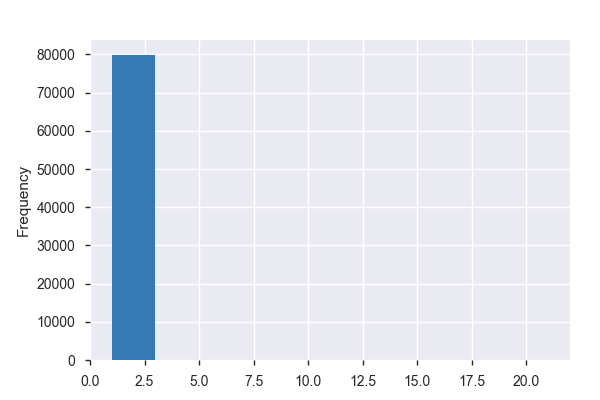

**Common Values**

| Value | Count | Frequency (%) |  |
| --- | --- | --- | --- |
| 1 | 79526 | 99.4% |  |
| 2 | 271 | 0.3% |  |
| 3 | 63 | 0.1% |  |
| 4 | 30 | 0.0% |  |
| 5 | 28 | 0.0% |  |
| 6 | 22 | 0.0% |  |
| 7 | 21 | 0.0% |  |
| 12 | 12 | 0.0% |  |
| 8 | 11 | 0.0% |  |
| 9 | 8 | 0.0% |  |
| Other values (8) | 18 | 0.0% |  |

**Extreme Values**

Minimum 5 values

| Value | Count | Frequency (%) |  |
| --- | --- | --- | --- |
| 1 | 79526 | 99.4% |  |
| 2 | 271 | 0.3% |  |
| 3 | 63 | 0.1% |  |
| 4 | 30 | 0.0% |  |
| 5 | 28 | 0.0% |  |

Maximum 5 values

| Value | Count | Frequency (%) |  |
| --- | --- | --- | --- |
| 14 | 2 | 0.0% |  |
| 15 | 2 | 0.0% |  |
| 17 | 2 | 0.0% |  |
| 19 | 1 | 0.0% |  |
| 21 | 1 | 0.0% |  |

Clase de empleado  
Categorical

| Distinct count | 33 |
| --- | --- |
| Unique (%) | 0.0% |
| Missing (%) | 0.0% |
| Missing (n) | 0 |

| EMPLEADO PARTICULAR | 46564 |
| --- | --- |
| INDEPENDIENTE | 15936 |
| ESTUDIANTE | 5720 |
| Other values (30) | 11790 |

Toggle details

| Value | Count | Frequency (%) |  |
| --- | --- | --- | --- |
| EMPLEADO PARTICULAR | 46564 | 58.2% |  |
| INDEPENDIENTE | 15936 | 19.9% |  |
| ESTUDIANTE | 5720 | 7.1% |  |
| AMA DE CASA | 2963 | 3.7% |  |
| COMERCIANTE | 2822 | 3.5% |  |
| PENSIONADO | 1276 | 1.6% |  |
| DESEMPLEADO | 1259 | 1.6% |  |
| EMPLEADO PUBLICO | 1194 | 1.5% |  |
| EMPLEADO POLICIAL | 481 | 0.6% |  |
| EMPLEADO SALUD | 400 | 0.5% |  |
| Other values (23) | 1395 | 1.7% |  |

Clase de sitio  
Categorical

| Distinct count | 333 |
| --- | --- |
| Unique (%) | 0.4% |
| Missing (%) | 0.0% |
| Missing (n) | 0 |

| VIAS PUBLICAS | 56010 |
| --- | --- |
| CASAS DE HABITACION | 2899 |
| LOCAL COMERCIAL | 1341 |
| Other values (330) | 19760 |

Toggle details

| Value | Count | Frequency (%) |  |
| --- | --- | --- | --- |
| VIAS PUBLICAS | 56010 | 70.0% |  |
| CASAS DE HABITACION | 2899 | 3.6% |  |
| LOCAL COMERCIAL | 1341 | 1.7% |  |
| FRENTE A RESIDENCIAS - VIA PUBLICA | 1184 | 1.5% |  |
| INTERIOR VEHICULO SERVICIO PUBLICO | 1019 | 1.3% |  |
| PARQUEADERO | 985 | 1.2% |  |
| INTERIOR VEHICULO PARTICULAR | 825 | 1.0% |  |
| SOBRE ANDEN - VIA PUBLICA | 782 | 1.0% |  |
| OFICINAS | 734 | 0.9% |  |
| FINCAS Y SIMILARES | 709 | 0.9% |  |
| Other values (323) | 13522 | 16.9% |  |

Código DANE  
Numeric

| Distinct count | 825 |
| --- | --- |
| Unique (%) | 1.0% |
| Missing (%) | 0.0% |
| Missing (n) | 0 |
| Infinite (%) | 0.0% |
| Infinite (n) | 0 |

| Mean | 32705000 |
| --- | --- |
| Minimum | 5001000 |
| Maximum | 99773000 |
| Zeros (%) | 0.0% |

Toggle details

**Statistics**

Quantile statistics

| Minimum | 5001000 |
| --- | --- |
| 5-th percentile | 5001000 |
| Q1 | 11001000 |
| Median | 17001000 |
| Q3 | 66001000 |
| 95-th percentile | 76001000 |
| Maximum | 99773000 |
| Range | 94772000 |
| Interquartile range | 55000000 |

Descriptive statistics

| Standard deviation | 27620000 |
| --- | --- |
| Coef of variation | 0.84454 |
| Kurtosis | -1.3801 |
| Mean | 32705000 |
| MAD | 25610000 |
| Skewness | 0.57148 |
| Sum | 2616691908000 |
| Variance | 762880000000000 |
| Memory size | 625.2 KiB |

**Histogram**

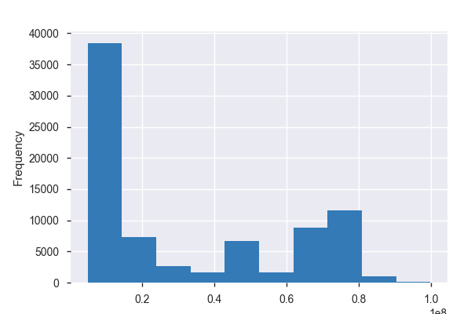

**Common Values**

| Value | Count | Frequency (%) |  |
| --- | --- | --- | --- |
| 11001000 | 23042 | 28.8% |  |
| 5001000 | 7196 | 9.0% |  |
| 76001000 | 6793 | 8.5% |  |
| 8001000 | 2982 | 3.7% |  |
| 52001000 | 2231 | 2.8% |  |
| 68001000 | 2181 | 2.7% |  |
| 50001000 | 1794 | 2.2% |  |
| 73001000 | 1554 | 1.9% |  |
| 66001000 | 1438 | 1.8% |  |
| 19001000 | 1234 | 1.5% |  |
| Other values (815) | 29565 | 37.0% |  |

**Extreme Values**

Minimum 5 values

| Value | Count | Frequency (%) |  |
| --- | --- | --- | --- |
| 5001000 | 7196 | 9.0% |  |
| 5002000 | 9 | 0.0% |  |
| 5004000 | 2 | 0.0% |  |
| 5030000 | 10 | 0.0% |  |
| 5031000 | 4 | 0.0% |  |

Maximum 5 values

| Value | Count | Frequency (%) |  |
| --- | --- | --- | --- |
| 95200000 | 1 | 0.0% |  |
| 97001000 | 6 | 0.0% |  |
| 99001000 | 15 | 0.0% |  |
| 99524000 | 2 | 0.0% |  |
| 99773000 | 1 | 0.0% |  |

Departamento  
Categorical

| Distinct count | 32 |
| --- | --- |
| Unique (%) | 0.0% |
| Missing (%) | 0.0% |
| Missing (n) | 0 |

| CUNDINAMARCA | 25307 |
| --- | --- |
| ANTIOQUIA | 10368 |
| VALLE | 9203 |
| Other values (29) | 35132 |

Toggle details

| Value | Count | Frequency (%) |  |
| --- | --- | --- | --- |
| CUNDINAMARCA | 25307 | 31.6% |  |
| ANTIOQUIA | 10368 | 13.0% |  |
| VALLE | 9203 | 11.5% |  |
| SANTANDER | 4477 | 5.6% |  |
| ATLÁNTICO | 3827 | 4.8% |  |
| NARIÑO | 2826 | 3.5% |  |
| TOLIMA | 2419 | 3.0% |  |
| META | 2091 | 2.6% |  |
| RISARALDA | 2013 | 2.5% |  |
| CAUCA | 1753 | 2.2% |  |
| Other values (22) | 15726 | 19.7% |  |

Día  
Categorical

| Distinct count | 7 |
| --- | --- |
| Unique (%) | 0.0% |
| Missing (%) | 0.0% |
| Missing (n) | 0 |

| Viernes | 12461 |
| --- | --- |
| Sábado | 12182 |
| Miércoles | 11940 |
| Other values (4) | 43427 |

Toggle details

| Value | Count | Frequency (%) |  |
| --- | --- | --- | --- |
| Viernes | 12461 | 15.6% |  |
| Sábado | 12182 | 15.2% |  |
| Miércoles | 11940 | 14.9% |  |
| Jueves | 11849 | 14.8% |  |
| Martes | 11743 | 14.7% |  |
| Lunes | 10849 | 13.6% |  |
| Domingo | 8986 | 11.2% |  |

Edad  
Categorical

| Distinct count | 96 |
| --- | --- |
| Unique (%) | 0.1% |
| Missing (%) | 0.0% |
| Missing (n) | 0 |

| - | 2994 |
| --- | --- |
| 26 | 2633 |
| 27 | 2587 |
| Other values (93) | 71796 |

Toggle details

| Value | Count | Frequency (%) |  |
| --- | --- | --- | --- |
| - | 2994 | 3.7% |  |
| 26 | 2633 | 3.3% |  |
| 27 | 2587 | 3.2% |  |
| 25 | 2561 | 3.2% |  |
| 28 | 2486 | 3.1% |  |
| 31 | 2392 | 3.0% |  |
| 24 | 2383 | 3.0% |  |
| 23 | 2352 | 2.9% |  |
| 30 | 2311 | 2.9% |  |
| 29 | 2308 | 2.9% |  |
| Other values (86) | 55003 | 68.7% |  |

Escolaridad  
Categorical

| Distinct count | 8 |
| --- | --- |
| Unique (%) | 0.0% |
| Missing (%) | 0.0% |
| Missing (n) | 0 |

| SECUNDARIA | 44613 |
| --- | --- |
| SUPERIOR | 14533 |
| PRIMARIA | 14066 |
| Other values (5) | 6798 |

Toggle details

| Value | Count | Frequency (%) |  |
| --- | --- | --- | --- |
| SECUNDARIA | 44613 | 55.8% |  |
| SUPERIOR | 14533 | 18.2% |  |
| PRIMARIA | 14066 | 17.6% |  |
| TECNICO | 5197 | 6.5% |  |
| TECNOLOGO | 1286 | 1.6% |  |
| NO REPORTADO | 154 | 0.2% |  |
| ANALFABETA | 124 | 0.2% |  |
| - | 37 | 0.0% |  |

Estado civil  
Categorical

| Distinct count | 7 |
| --- | --- |
| Unique (%) | 0.0% |
| Missing (%) | 0.0% |
| Missing (n) | 0 |

| SOLTERO | 41862 |
| --- | --- |
| UNION LIBRE | 19117 |
| CASADO | 15833 |
| Other values (4) | 3198 |

Toggle details

| Value | Count | Frequency (%) |  |
| --- | --- | --- | --- |
| SOLTERO | 41862 | 52.3% |  |
| UNION LIBRE | 19117 | 23.9% |  |
| CASADO | 15833 | 19.8% |  |
| DIVORCIADO | 1331 | 1.7% |  |
| VIUDO | 943 | 1.2% |  |
| SEPARADO | 873 | 1.1% |  |
| - | 51 | 0.1% |  |

Fecha  
Date

| Distinct count | 212 |
| --- | --- |
| Unique (%) | 0.3% |
| Missing (%) | 0.0% |
| Missing (n) | 0 |
| Infinite (%) | 0.0% |
| Infinite (n) | 0 |

| Minimum | 2017-01-01 00:00:00 |
| --- | --- |
| Maximum | 2017-07-31 00:00:00 |

Toggle details

[figure not shown]

Hora  
Date

| Distinct count | 1274 |
| --- | --- |
| Unique (%) | 1.6% |
| Missing (%) | 0.0% |
| Missing (n) | 0 |
| Infinite (%) | 0.0% |
| Infinite (n) | 0 |

| Minimum | 1899-12-31 00:00:00 |
| --- | --- |
| Maximum | 1899-12-31 23:59:00 |

Toggle details

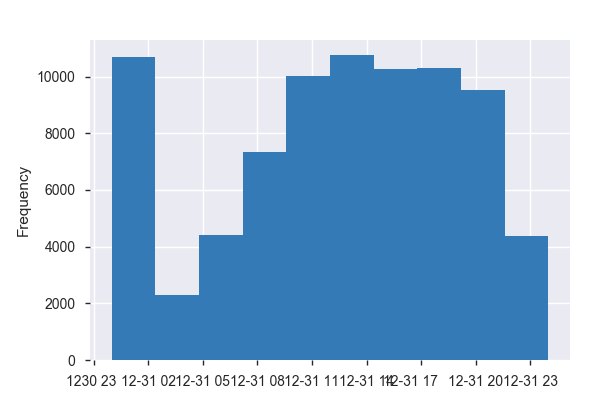

Municipio  
Categorical

| Distinct count | 774 |
| --- | --- |
| Unique (%) | 1.0% |
| Missing (%) | 0.0% |
| Missing (n) | 0 |

| BOGOTÁ D.C. (CT) | 23042 |
| --- | --- |
| MEDELLÍN (CT) | 7196 |
| CALI (CT) | 6793 |
| Other values (771) | 42979 |

Toggle details

| Value | Count | Frequency (%) |  |
| --- | --- | --- | --- |
| BOGOTÁ D.C. (CT) | 23042 | 28.8% |  |
| MEDELLÍN (CT) | 7196 | 9.0% |  |
| CALI (CT) | 6793 | 8.5% |  |
| BARRANQUILLA (CT) | 2982 | 3.7% |  |
| PASTO (CT) | 2231 | 2.8% |  |
| BUCARAMANGA (CT) | 2181 | 2.7% |  |
| VILLAVICENCIO (CT) | 1794 | 2.2% |  |
| IBAGUÉ (CT) | 1554 | 1.9% |  |
| PEREIRA (CT) | 1438 | 1.8% |  |
| POPAYÁN (CT) | 1234 | 1.5% |  |
| Other values (764) | 29565 | 37.0% |  |

Móvil Agresor  
Categorical

| Distinct count | 15 |
| --- | --- |
| Unique (%) | 0.0% |
| Missing (%) | 0.0% |
| Missing (n) | 0 |

| A PIE | 59978 |
| --- | --- |
| PASAJERO MOTOCICLETA | 9511 |
| CONDUCTOR MOTOCICLETA | 4305 |
| Other values (12) | 6216 |

Toggle details

| Value | Count | Frequency (%) |  |
| --- | --- | --- | --- |
| A PIE | 59978 | 75.0% |  |
| PASAJERO MOTOCICLETA | 9511 | 11.9% |  |
| CONDUCTOR MOTOCICLETA | 4305 | 5.4% |  |
| PASAJERO BUS | 2305 | 2.9% |  |
| BICICLETA | 1407 | 1.8% |  |
| CONDUCTOR VEHICULO | 663 | 0.8% |  |
| PASAJERO TAXI | 625 | 0.8% |  |
| CONDUCTOR TAXI | 490 | 0.6% |  |
| PASAJERO VEHICULO | 466 | 0.6% |  |
| PASAJERO METRO | 196 | 0.2% |  |
| Other values (5) | 64 | 0.1% |  |

Móvil Victima  
Categorical

| Distinct count | 14 |
| --- | --- |
| Unique (%) | 0.0% |
| Missing (%) | 0.0% |
| Missing (n) | 0 |

| A PIE | 66076 |
| --- | --- |
| CONDUCTOR VEHICULO | 4641 |
| CONDUCTOR MOTOCICLETA | 2424 |
| Other values (11) | 6869 |

Toggle details

| Value | Count | Frequency (%) |  |
| --- | --- | --- | --- |
| A PIE | 66076 | 82.6% |  |
| CONDUCTOR VEHICULO | 4641 | 5.8% |  |
| CONDUCTOR MOTOCICLETA | 2424 | 3.0% |  |
| PASAJERO BUS | 2408 | 3.0% |  |
| BICICLETA | 1593 | 2.0% |  |
| PASAJERO TAXI | 663 | 0.8% |  |
| CONDUCTOR TAXI | 624 | 0.8% |  |
| PASAJERO MOTOCICLETA | 535 | 0.7% |  |
| PASAJERO VEHICULO | 518 | 0.6% |  |
| CONDUCTOR BUS | 302 | 0.4% |  |
| Other values (4) | 226 | 0.3% |  |

País de nacimiento  
Categorical

| Distinct count | 72 |
| --- | --- |
| Unique (%) | 0.1% |
| Missing (%) | 0.0% |
| Missing (n) | 0 |

| COLOMBIA | 78702 |
| --- | --- |
| - | 234 |
| VENEZUELA | 191 |
| Other values (69) | 883 |

Toggle details

| Value | Count | Frequency (%) |  |
| --- | --- | --- | --- |
| COLOMBIA | 78702 | 98.4% |  |
| - | 234 | 0.3% |  |
| VENEZUELA | 191 | 0.2% |  |
| ESTADOS UNIDOS | 135 | 0.2% |  |
| ECUADOR | 59 | 0.1% |  |
| FRANCIA | 53 | 0.1% |  |
| BRASIL | 48 | 0.1% |  |
| ARGENTINA | 44 | 0.1% |  |
| MEXICO | 43 | 0.1% |  |
| AUSTRALIA | 43 | 0.1% |  |
| Other values (62) | 458 | 0.6% |  |

Profesión  
Categorical

| Distinct count | 109 |
| --- | --- |
| Unique (%) | 0.1% |
| Missing (%) | 0.0% |
| Missing (n) | 0 |

| - | 69777 |
| --- | --- |
| ADMINISTRADOR DE EMPRESAS | 1363 |
| LICENCIADO | 751 |
| Other values (106) | 8119 |

Toggle details

| Value | Count | Frequency (%) |  |
| --- | --- | --- | --- |
| - | 69777 | 87.2% |  |
| ADMINISTRADOR DE EMPRESAS | 1363 | 1.7% |  |
| LICENCIADO | 751 | 0.9% |  |
| ABOGADO | 746 | 0.9% |  |
| INGENIERO | 655 | 0.8% |  |
| TECNICO EMPRESARIAL | 542 | 0.7% |  |
| TECNICO EN SISTEMAS | 418 | 0.5% |  |
| POLICIA | 414 | 0.5% |  |
| CONTADOR PUBLICO | 354 | 0.4% |  |
| INGENIERO DE SISTEMAS | 313 | 0.4% |  |
| Other values (99) | 4677 | 5.8% |  |

Sexo  
Categorical

| Distinct count | 3 |
| --- | --- |
| Unique (%) | 0.0% |
| Missing (%) | 0.0% |
| Missing (n) | 0 |

| MASCULINO | 47082 |
| --- | --- |
| FEMENINO | 32927 |
| - | 1 |

Toggle details

| Value | Count | Frequency (%) |  |
| --- | --- | --- | --- |
| MASCULINO | 47082 | 58.8% |  |
| FEMENINO | 32927 | 41.2% |  |
| - | 1 | 0.0% |  |

Zona  
Categorical

| Distinct count | 3 |
| --- | --- |
| Unique (%) | 0.0% |
| Missing (%) | 0.0% |
| Missing (n) | 0 |

| URBANA | 76308 |
| --- | --- |
| RURAL | 3698 |
| OTRAS | 4 |

Toggle details

| Value | Count | Frequency (%) |  |
| --- | --- | --- | --- |
| URBANA | 76308 | 95.4% |  |
| RURAL | 3698 | 4.6% |  |
| OTRAS | 4 | 0.0% |  |

Sample

|  | Fecha | Departamento | Municipio | Día | Hora | Barrio | Zona | Clase de sitio | Arma empleada | Móvil Agresor | Móvil Victima | Edad | Sexo | Estado civil | País de nacimiento | Clase de empleado | Profesión | Escolaridad | Código DANE | Cantidad |
| --- | --- | --- | --- | --- | --- | --- | --- | --- | --- | --- | --- | --- | --- | --- | --- | --- | --- | --- | --- | --- |
| 0 | 2017-01-01 | ANTIOQUIA | APARTADÓ | Domingo | 1899-12-31 00:00:00 | VILLA DEL RIO CASAS BLANCAS | URBANA | VIAS PUBLICAS | SIN EMPLEO DE ARMAS | A PIE | A PIE | 60 | FEMENINO | VIUDO | COLOMBIA | EMPLEADO PARTICULAR | - | PRIMARIA | 5045000 | 1 |
| 1 | 2017-01-01 | ANTIOQUIA | APARTADÓ | Domingo | 1899-12-31 00:00:00 | VILLA DEL RIO CASAS BLANCAS | URBANA | VIAS PUBLICAS | SIN EMPLEO DE ARMAS | A PIE | A PIE | 65 | MASCULINO | CASADO | COLOMBIA | EMPLEADO PARTICULAR | - | PRIMARIA | 5045000 | 1 |
| 2 | 2017-01-01 | ANTIOQUIA | BELLO | Domingo | 1899-12-31 19:00:00 | CIUDADELA DEL NORTE | URBANA | VIAS PUBLICAS | ARMA DE FUEGO | A PIE | A PIE | 31 | FEMENINO | SOLTERO | COLOMBIA | EMPLEADO PARTICULAR | - | PRIMARIA | 5088000 | 1 |
| 3 | 2017-01-01 | ANTIOQUIA | BELLO | Domingo | 1899-12-31 00:00:00 | VDA. SAN FELIX | RURAL | VIAS PUBLICAS | ARMA DE FUEGO | A PIE | A PIE | 33 | MASCULINO | SOLTERO | COLOMBIA | EMPLEADO PARTICULAR | - | SECUNDARIA | 5088000 | 1 |
| 4 | 2017-01-01 | ANTIOQUIA | BELLO | Domingo | 1899-12-31 01:00:00 | PARIS CENTRAL | URBANA | VIAS PUBLICAS | SIN EMPLEO DE ARMAS | A PIE | A PIE | 19 | MASCULINO | SOLTERO | COLOMBIA | DESEMPLEADO | - | SECUNDARIA | 5088000 | 1 |

```python
pandas_profiling.ProfileReport(hp2017)
```

Overview

Dataset info

| Number of variables | 20 |
| --- | --- |
| Number of observations | 146068 |
| Total Missing (%) | 0.0% |
| Total size in memory | 22.3 MiB |
| Average record size in memory | 160.0 B |

Variables types

| Numeric | 2 |
| --- | --- |
| Categorical | 16 |
| Date | 2 |
| Text (Unique) | 0 |
| Rejected | 0 |

Warnings

- `Barrio` has a high cardinality: 12818 distinct values Warning

- `Cantidad` is highly skewed (γ1 = 50.214)

- `Clase de sitio` has a high cardinality: 347 distinct values Warning

- `Edad` has a high cardinality: 97 distinct values Warning

- `Municipio` has a high cardinality: 917 distinct values Warning

- `País de nacimiento` has a high cardinality: 93 distinct values Warning

- `Profesión` has a high cardinality: 106 distinct values Warning

Variables

Arma empleada  
Categorical

| Distinct count | 9 |
| --- | --- |
| Unique (%) | 0.0% |
| Missing (%) | 0.0% |
| Missing (n) | 0 |

| SIN EMPLEO DE ARMAS | 74836 |
| --- | --- |
| ARMA DE FUEGO | 27302 |
| ARMA BLANCA / CORTOPUNZANTE | 27203 |
| Other values (6) | 16727 |

Toggle details

| Value | Count | Frequency (%) |  |
| --- | --- | --- | --- |
| SIN EMPLEO DE ARMAS | 74836 | 51.2% |  |
| ARMA DE FUEGO | 27302 | 18.7% |  |
| ARMA BLANCA / CORTOPUNZANTE | 27203 | 18.6% |  |
| CONTUNDENTES | 15017 | 10.3% |  |
| ESCOPOLAMINA | 1403 | 1.0% |  |
| CORTANTES | 217 | 0.1% |  |
| PERRO | 70 | 0.0% |  |
| ARMAS BLANCAS | 13 | 0.0% |  |
| JERINGA | 7 | 0.0% |  |

Barrio  
Categorical

| Distinct count | 12818 |
| --- | --- |
| Unique (%) | 8.8% |
| Missing (%) | 0.0% |
| Missing (n) | 0 |

| CENTRO | 7219 |
| --- | --- |
| LA CANDELARIA C-10 | 2317 |
| EL CENTRO | 931 |
| Other values (12815) | 135601 |

Toggle details

| Value | Count | Frequency (%) |  |
| --- | --- | --- | --- |
| CENTRO | 7219 | 4.9% |  |
| LA CANDELARIA C-10 | 2317 | 1.6% |  |
| EL CENTRO | 931 | 0.6% |  |
| NELSON MANDELA | 842 | 0.6% |  |
| SAN FRANCISCO | 560 | 0.4% |  |
| TIERRA GRATA | 559 | 0.4% |  |
| JUAN PABLO I | 530 | 0.4% |  |
| ZONA CENTRO | 477 | 0.3% |  |
| BARRIO CENTRO | 474 | 0.3% |  |
| EL POBLADO C-14 | 468 | 0.3% |  |
| Other values (12808) | 131691 | 90.2% |  |

Cantidad  
Numeric

| Distinct count | 9 |
| --- | --- |
| Unique (%) | 0.0% |
| Missing (%) | 0.0% |
| Missing (n) | 0 |
| Infinite (%) | 0.0% |
| Infinite (n) | 0 |

| Mean | 1.0036 |
| --- | --- |
| Minimum | 1 |
| Maximum | 13 |
| Zeros (%) | 0.0% |

Toggle details

**Statistics**

Quantile statistics

| Minimum | 1 |
| --- | --- |
| 5-th percentile | 1 |
| Q1 | 1 |
| Median | 1 |
| Q3 | 1 |
| 95-th percentile | 1 |
| Maximum | 13 |
| Range | 12 |
| Interquartile range | 0 |

Descriptive statistics

| Standard deviation | 0.081116 |
| --- | --- |
| Coef of variation | 0.080823 |
| Kurtosis | 4850.4 |
| Mean | 1.0036 |
| MAD | 0.0072217 |
| Skewness | 50.214 |
| Sum | 146597 |
| Variance | 0.0065797 |
| Memory size | 1.1 MiB |

**Histogram**

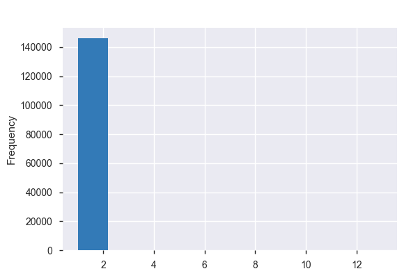

**Common Values**

| Value | Count | Frequency (%) |  |
| --- | --- | --- | --- |
| 1 | 145635 | 99.7% |  |
| 2 | 381 | 0.3% |  |
| 3 | 32 | 0.0% |  |
| 4 | 12 | 0.0% |  |
| 5 | 4 | 0.0% |  |
| 13 | 1 | 0.0% |  |
| 9 | 1 | 0.0% |  |
| 8 | 1 | 0.0% |  |
| 6 | 1 | 0.0% |  |

**Extreme Values**

Minimum 5 values

| Value | Count | Frequency (%) |  |
| --- | --- | --- | --- |
| 1 | 145635 | 99.7% |  |
| 2 | 381 | 0.3% |  |
| 3 | 32 | 0.0% |  |
| 4 | 12 | 0.0% |  |
| 5 | 4 | 0.0% |  |

Maximum 5 values

| Value | Count | Frequency (%) |  |
| --- | --- | --- | --- |
| 5 | 4 | 0.0% |  |
| 6 | 1 | 0.0% |  |
| 8 | 1 | 0.0% |  |
| 9 | 1 | 0.0% |  |
| 13 | 1 | 0.0% |  |

Clase de empleado  
Categorical

| Distinct count | 36 |
| --- | --- |
| Unique (%) | 0.0% |
| Missing (%) | 0.0% |
| Missing (n) | 0 |

| EMPLEADO PARTICULAR | 87294 |
| --- | --- |
| INDEPENDIENTE | 29126 |
| ESTUDIANTE | 8528 |
| Other values (33) | 21120 |

Toggle details

| Value | Count | Frequency (%) |  |
| --- | --- | --- | --- |
| EMPLEADO PARTICULAR | 87294 | 59.8% |  |
| INDEPENDIENTE | 29126 | 19.9% |  |
| ESTUDIANTE | 8528 | 5.8% |  |
| COMERCIANTE | 5311 | 3.6% |  |
| AMA DE CASA | 5027 | 3.4% |  |
| EMPLEADO PUBLICO | 2108 | 1.4% |  |
| PENSIONADO | 1939 | 1.3% |  |
| DESEMPLEADO | 1844 | 1.3% |  |
| NO REPORTA | 1310 | 0.9% |  |
| EMPLEADO POLICIAL | 1017 | 0.7% |  |
| Other values (26) | 2564 | 1.8% |  |

Clase de sitio  
Categorical

| Distinct count | 347 |
| --- | --- |
| Unique (%) | 0.2% |
| Missing (%) | 0.0% |
| Missing (n) | 0 |

| VIAS PUBLICAS | 104712 |
| --- | --- |
| CASAS DE HABITACION | 4557 |
| LOCAL COMERCIAL | 2157 |
| Other values (344) | 34642 |

Toggle details

| Value | Count | Frequency (%) |  |
| --- | --- | --- | --- |
| VIAS PUBLICAS | 104712 | 71.7% |  |
| CASAS DE HABITACION | 4557 | 3.1% |  |
| LOCAL COMERCIAL | 2157 | 1.5% |  |
| FRENTE A RESIDENCIAS - VIA PUBLICA | 2003 | 1.4% |  |
| PARQUEADERO | 1871 | 1.3% |  |
| CAJERO AUTOMATICO | 1866 | 1.3% |  |
| INTERIOR VEHICULO SERVICIO PUBLICO | 1698 | 1.2% |  |
| INTERIOR VEHICULO PARTICULAR | 1499 | 1.0% |  |
| OFICINAS | 1387 | 0.9% |  |
| FINCAS Y SIMILARES | 1334 | 0.9% |  |
| Other values (337) | 22984 | 15.7% |  |

Código DANE  
Numeric

| Distinct count | 983 |
| --- | --- |
| Unique (%) | 0.7% |
| Missing (%) | 0.0% |
| Missing (n) | 0 |
| Infinite (%) | 0.0% |
| Infinite (n) | 0 |

| Mean | 32602000 |
| --- | --- |
| Minimum | 5001000 |
| Maximum | 99773000 |
| Zeros (%) | 0.0% |

Toggle details

**Statistics**

Quantile statistics

| Minimum | 5001000 |
| --- | --- |
| 5-th percentile | 5001000 |
| Q1 | 11001000 |
| Median | 17174000 |
| Q3 | 66001000 |
| 95-th percentile | 76001000 |
| Maximum | 99773000 |
| Range | 94772000 |
| Interquartile range | 55000000 |

Descriptive statistics

| Standard deviation | 27492000 |
| --- | --- |
| Coef of variation | 0.84327 |
| Kurtosis | -1.3496 |
| Mean | 32602000 |
| MAD | 25377000 |
| Skewness | 0.57865 |
| Sum | 4762128585000 |
| Variance | 755840000000000 |
| Memory size | 1.1 MiB |

**Histogram**

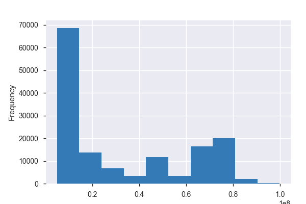

**Common Values**

| Value | Count | Frequency (%) |  |
| --- | --- | --- | --- |
| 11001000 | 37769 | 25.9% |  |
| 5001000 | 13375 | 9.2% |  |
| 76001000 | 10352 | 7.1% |  |
| 8001000 | 5285 | 3.6% |  |
| 68001000 | 4166 | 2.9% |  |
| 50001000 | 3693 | 2.5% |  |
| 52001000 | 3523 | 2.4% |  |
| 73001000 | 3093 | 2.1% |  |
| 19001000 | 2410 | 1.6% |  |
| 41001000 | 2314 | 1.6% |  |
| Other values (973) | 60088 | 41.1% |  |

**Extreme Values**

Minimum 5 values

| Value | Count | Frequency (%) |  |
| --- | --- | --- | --- |
| 5001000 | 13375 | 9.2% |  |
| 5002000 | 23 | 0.0% |  |
| 5021000 | 5 | 0.0% |  |
| 5030000 | 44 | 0.0% |  |
| 5031000 | 71 | 0.0% |  |

Maximum 5 values

| Value | Count | Frequency (%) |  |
| --- | --- | --- | --- |
| 97001000 | 8 | 0.0% |  |
| 99001000 | 45 | 0.0% |  |
| 99524000 | 5 | 0.0% |  |
| 99624000 | 1 | 0.0% |  |
| 99773000 | 8 | 0.0% |  |

Departamento  
Categorical

| Distinct count | 32 |
| --- | --- |
| Unique (%) | 0.0% |
| Missing (%) | 0.0% |
| Missing (n) | 0 |

| CUNDINAMARCA | 43682 |
| --- | --- |
| ANTIOQUIA | 21092 |
| VALLE | 14672 |
| Other values (29) | 66622 |

Toggle details

| Value | Count | Frequency (%) |  |
| --- | --- | --- | --- |
| CUNDINAMARCA | 43682 | 29.9% |  |
| ANTIOQUIA | 21092 | 14.4% |  |
| VALLE | 14672 | 10.0% |  |
| SANTANDER | 8468 | 5.8% |  |
| ATLÁNTICO | 6722 | 4.6% |  |
| TOLIMA | 5421 | 3.7% |  |
| NARIÑO | 4827 | 3.3% |  |
| META | 4417 | 3.0% |  |
| CAUCA | 3432 | 2.3% |  |
| HUILA | 3412 | 2.3% |  |
| Other values (22) | 29923 | 20.5% |  |

Día  
Categorical

| Distinct count | 7 |
| --- | --- |
| Unique (%) | 0.0% |
| Missing (%) | 0.0% |
| Missing (n) | 0 |

| Viernes | 23134 |
| --- | --- |
| Jueves | 22111 |
| Sábado | 21767 |
| Other values (4) | 79056 |

Toggle details

| Value | Count | Frequency (%) |  |
| --- | --- | --- | --- |
| Viernes | 23134 | 15.8% |  |
| Jueves | 22111 | 15.1% |  |
| Sábado | 21767 | 14.9% |  |
| Miércoles | 21735 | 14.9% |  |
| Martes | 21253 | 14.6% |  |
| Lunes | 20055 | 13.7% |  |
| Domingo | 16013 | 11.0% |  |

Edad  
Categorical

| Distinct count | 97 |
| --- | --- |
| Unique (%) | 0.1% |
| Missing (%) | 0.0% |
| Missing (n) | 0 |

| - | 8815 |
| --- | --- |
| 25 | 4554 |
| 26 | 4533 |
| Other values (94) | 128166 |

Toggle details

| Value | Count | Frequency (%) |  |
| --- | --- | --- | --- |
| - | 8815 | 6.0% |  |
| 25 | 4554 | 3.1% |  |
| 26 | 4533 | 3.1% |  |
| 27 | 4476 | 3.1% |  |
| 36 | 4398 | 3.0% |  |
| 30 | 4321 | 3.0% |  |
| 28 | 4295 | 2.9% |  |
| 31 | 4263 | 2.9% |  |
| 29 | 4219 | 2.9% |  |
| 35 | 4217 | 2.9% |  |
| Other values (87) | 97977 | 67.1% |  |

Escolaridad  
Categorical

| Distinct count | 8 |
| --- | --- |
| Unique (%) | 0.0% |
| Missing (%) | 0.0% |
| Missing (n) | 0 |

| SECUNDARIA | 81535 |
| --- | --- |
| PRIMARIA | 30786 |
| SUPERIOR | 23067 |
| Other values (5) | 10680 |

Toggle details

| Value | Count | Frequency (%) |  |
| --- | --- | --- | --- |
| SECUNDARIA | 81535 | 55.8% |  |
| PRIMARIA | 30786 | 21.1% |  |
| SUPERIOR | 23067 | 15.8% |  |
| TECNICO | 8284 | 5.7% |  |
| TECNOLOGO | 1708 | 1.2% |  |
| NO REPORTADO | 320 | 0.2% |  |
| ANALFABETA | 218 | 0.1% |  |
| - | 150 | 0.1% |  |

Estado civil  
Categorical

| Distinct count | 7 |
| --- | --- |
| Unique (%) | 0.0% |
| Missing (%) | 0.0% |
| Missing (n) | 0 |

| SOLTERO | 76440 |
| --- | --- |
| UNION LIBRE | 35329 |
| CASADO | 28769 |
| Other values (4) | 5530 |

Toggle details

| Value | Count | Frequency (%) |  |
| --- | --- | --- | --- |
| SOLTERO | 76440 | 52.3% |  |
| UNION LIBRE | 35329 | 24.2% |  |
| CASADO | 28769 | 19.7% |  |
| DIVORCIADO | 2212 | 1.5% |  |
| VIUDO | 1670 | 1.1% |  |
| SEPARADO | 1371 | 0.9% |  |
| - | 277 | 0.2% |  |

Fecha  
Date

| Distinct count | 366 |
| --- | --- |
| Unique (%) | 0.3% |
| Missing (%) | 0.0% |
| Missing (n) | 0 |
| Infinite (%) | 0.0% |
| Infinite (n) | 0 |

| Minimum | 2016-01-01 00:00:00 |
| --- | --- |
| Maximum | 2016-12-31 00:00:00 |

Toggle details

[figure not shown]

Hora  
Date

| Distinct count | 1395 |
| --- | --- |
| Unique (%) | 1.0% |
| Missing (%) | 0.0% |
| Missing (n) | 0 |
| Infinite (%) | 0.0% |
| Infinite (n) | 0 |

| Minimum | 1899-12-31 00:00:00 |
| --- | --- |
| Maximum | 1899-12-31 23:59:00 |

Toggle details

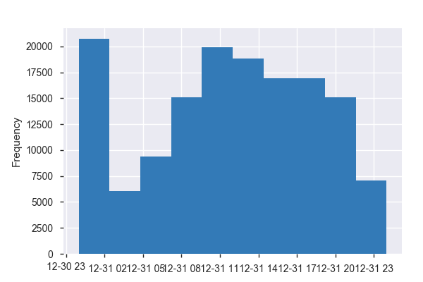

Municipio  
Categorical

| Distinct count | 917 |
| --- | --- |
| Unique (%) | 0.6% |
| Missing (%) | 0.0% |
| Missing (n) | 0 |

| BOGOTÁ D.C. (CT) | 37769 |
| --- | --- |
| MEDELLÍN (CT) | 13375 |
| CALI (CT) | 10352 |
| Other values (914) | 84572 |

Toggle details

| Value | Count | Frequency (%) |  |
| --- | --- | --- | --- |
| BOGOTÁ D.C. (CT) | 37769 | 25.9% |  |
| MEDELLÍN (CT) | 13375 | 9.2% |  |
| CALI (CT) | 10352 | 7.1% |  |
| BARRANQUILLA (CT) | 5285 | 3.6% |  |
| BUCARAMANGA (CT) | 4166 | 2.9% |  |
| VILLAVICENCIO (CT) | 3693 | 2.5% |  |
| PASTO (CT) | 3523 | 2.4% |  |
| IBAGUÉ (CT) | 3093 | 2.1% |  |
| POPAYÁN (CT) | 2410 | 1.6% |  |
| NEIVA (CT) | 2314 | 1.6% |  |
| Other values (907) | 60088 | 41.1% |  |

Móvil Agresor  
Categorical

| Distinct count | 14 |
| --- | --- |
| Unique (%) | 0.0% |
| Missing (%) | 0.0% |
| Missing (n) | 0 |

| A PIE | 113620 |
| --- | --- |
| PASAJERO MOTOCICLETA | 16377 |
| CONDUCTOR MOTOCICLETA | 6615 |
| Other values (11) | 9456 |

Toggle details

| Value | Count | Frequency (%) |  |
| --- | --- | --- | --- |
| A PIE | 113620 | 77.8% |  |
| PASAJERO MOTOCICLETA | 16377 | 11.2% |  |
| CONDUCTOR MOTOCICLETA | 6615 | 4.5% |  |
| PASAJERO BUS | 3234 | 2.2% |  |
| CONDUCTOR VEHICULO | 1839 | 1.3% |  |
| BICICLETA | 1711 | 1.2% |  |
| PASAJERO TAXI | 1044 | 0.7% |  |
| CONDUCTOR TAXI | 956 | 0.7% |  |
| PASAJERO METRO | 323 | 0.2% |  |
| PASAJERO VEHICULO | 266 | 0.2% |  |
| Other values (4) | 83 | 0.1% |  |

Móvil Victima  
Categorical

| Distinct count | 14 |
| --- | --- |
| Unique (%) | 0.0% |
| Missing (%) | 0.0% |
| Missing (n) | 0 |

| A PIE | 121657 |
| --- | --- |
| CONDUCTOR VEHICULO | 9823 |
| CONDUCTOR MOTOCICLETA | 4533 |
| Other values (11) | 10055 |

Toggle details

| Value | Count | Frequency (%) |  |
| --- | --- | --- | --- |
| A PIE | 121657 | 83.3% |  |
| CONDUCTOR VEHICULO | 9823 | 6.7% |  |
| CONDUCTOR MOTOCICLETA | 4533 | 3.1% |  |
| PASAJERO BUS | 3173 | 2.2% |  |
| BICICLETA | 2328 | 1.6% |  |
| PASAJERO TAXI | 1249 | 0.9% |  |
| PASAJERO MOTOCICLETA | 1016 | 0.7% |  |
| CONDUCTOR TAXI | 1006 | 0.7% |  |
| CONDUCTOR BUS | 640 | 0.4% |  |
| PASAJERO VEHICULO | 315 | 0.2% |  |
| Other values (4) | 328 | 0.2% |  |

País de nacimiento  
Categorical

| Distinct count | 93 |
| --- | --- |
| Unique (%) | 0.1% |
| Missing (%) | 0.0% |
| Missing (n) | 0 |

| COLOMBIA | 144156 |
| --- | --- |
| VENEZUELA | 327 |
| ESTADOS UNIDOS | 228 |
| Other values (90) | 1357 |

Toggle details

| Value | Count | Frequency (%) |  |
| --- | --- | --- | --- |
| COLOMBIA | 144156 | 98.7% |  |
| VENEZUELA | 327 | 0.2% |  |
| ESTADOS UNIDOS | 228 | 0.2% |  |
| ECUADOR | 133 | 0.1% |  |
| ESPAÑA | 121 | 0.1% |  |
| - | 106 | 0.1% |  |
| FRANCIA | 71 | 0.0% |  |
| BRASIL | 68 | 0.0% |  |
| ITALIA | 65 | 0.0% |  |
| ALEMANIA | 64 | 0.0% |  |
| Other values (83) | 729 | 0.5% |  |

Profesión  
Categorical

| Distinct count | 106 |
| --- | --- |
| Unique (%) | 0.1% |
| Missing (%) | 0.0% |
| Missing (n) | 0 |

| - | 130713 |
| --- | --- |
| ADMINISTRADOR DE EMPRESAS | 2049 |
| ABOGADO | 1193 |
| Other values (103) | 12113 |

Toggle details

| Value | Count | Frequency (%) |  |
| --- | --- | --- | --- |
| - | 130713 | 89.5% |  |
| ADMINISTRADOR DE EMPRESAS | 2049 | 1.4% |  |
| ABOGADO | 1193 | 0.8% |  |
| INGENIERO | 1115 | 0.8% |  |
| LICENCIADO | 1104 | 0.8% |  |
| POLICIA | 957 | 0.7% |  |
| TECNICO EN SISTEMAS | 672 | 0.5% |  |
| TECNICO EMPRESARIAL | 639 | 0.4% |  |
| CONTADOR PUBLICO | 491 | 0.3% |  |
| INGENIERO DE SISTEMAS | 466 | 0.3% |  |
| Other values (96) | 6669 | 4.6% |  |

Sexo  
Categorical

| Distinct count | 3 |
| --- | --- |
| Unique (%) | 0.0% |
| Missing (%) | 0.0% |
| Missing (n) | 0 |

| MASCULINO | 86450 |
| --- | --- |
| FEMENINO | 59610 |
| - | 8 |

Toggle details

| Value | Count | Frequency (%) |  |
| --- | --- | --- | --- |
| MASCULINO | 86450 | 59.2% |  |
| FEMENINO | 59610 | 40.8% |  |
| - | 8 | 0.0% |  |

Zona  
Categorical

| Distinct count | 3 |
| --- | --- |
| Unique (%) | 0.0% |
| Missing (%) | 0.0% |
| Missing (n) | 0 |

| URBANA | 139624 |
| --- | --- |
| RURAL | 6442 |
| OTRAS | 2 |

Toggle details

| Value | Count | Frequency (%) |  |
| --- | --- | --- | --- |
| URBANA | 139624 | 95.6% |  |
| RURAL | 6442 | 4.4% |  |
| OTRAS | 2 | 0.0% |  |

Sample

|  | Fecha | Departamento | Municipio | Día | Hora | Barrio | Zona | Clase de sitio | Arma empleada | Móvil Agresor | Móvil Victima | Edad | Sexo | Estado civil | País de nacimiento | Clase de empleado | Profesión | Escolaridad | Código DANE | Cantidad |
| --- | --- | --- | --- | --- | --- | --- | --- | --- | --- | --- | --- | --- | --- | --- | --- | --- | --- | --- | --- | --- |
| 0 | 2016-01-01 | ANTIOQUIA | MEDELLÍN (CT) | Viernes | 1899-12-31 10:00:00 | CASTILLA C-5 | URBANA | CASAS DE HABITACION | SIN EMPLEO DE ARMAS | A PIE | A PIE | 59 | FEMENINO | CASADO | COLOMBIA | EMPLEADO PARTICULAR | - | SECUNDARIA | 5001000 | 1 |
| 1 | 2016-01-01 | ANTIOQUIA | MEDELLÍN (CT) | Viernes | 1899-12-31 10:00:00 | LA CANDELARIA C-10 | URBANA | VIAS PUBLICAS | SIN EMPLEO DE ARMAS | A PIE | A PIE | 37 | MASCULINO | UNION LIBRE | COLOMBIA | EMPLEADO PARTICULAR | - | SECUNDARIA | 5001000 | 1 |
| 2 | 2016-01-01 | ANTIOQUIA | MEDELLÍN (CT) | Viernes | 1899-12-31 16:00:00 | LAURELES C-11 | URBANA | CASAS DE HABITACION | SIN EMPLEO DE ARMAS | A PIE | A PIE | 24 | MASCULINO | SOLTERO | COLOMBIA | EMPLEADO PARTICULAR | - | SECUNDARIA | 5001000 | 1 |
| 3 | 2016-01-01 | ANTIOQUIA | MEDELLÍN (CT) | Viernes | 1899-12-31 16:00:00 | LLANADITAS C-8 | URBANA | VIAS PUBLICAS | SIN EMPLEO DE ARMAS | A PIE | A PIE | 49 | FEMENINO | SOLTERO | COLOMBIA | EMPLEADO PARTICULAR | - | SECUNDARIA | 5001000 | 1 |
| 4 | 2016-01-01 | ANTIOQUIA | MEDELLÍN (CT) | Viernes | 1899-12-31 16:00:00 | MONTECLARO C-7 | URBANA | CASAS DE HABITACION | CONTUNDENTES | A PIE | A PIE | 48 | MASCULINO | CASADO | COLOMBIA | EMPLEADO PARTICULAR | - | SECUNDARIA | 5001000 | 1 |

```python
pandas_profiling.ProfileReport(hp2016)
```

Overview

Dataset info

| Number of variables | 21 |
| --- | --- |
| Number of observations | 101284 |
| Total Missing (%) | 0.0% |
| Total size in memory | 16.2 MiB |
| Average record size in memory | 168.0 B |

Variables types

| Numeric | 2 |
| --- | --- |
| Categorical | 16 |
| Date | 2 |
| Text (Unique) | 1 |
| Rejected | 0 |

Warnings

- `Barrio` has a high cardinality: 11091 distinct values Warning

- `Cantidad` is highly skewed (γ1 = 50.501)

- `Clase de sitio` has a high cardinality: 321 distinct values Warning

- `Edad` has a high cardinality: 96 distinct values Warning

- `Municipio` has a high cardinality: 814 distinct values Warning

- `País de nacimiento` has a high cardinality: 70 distinct values Warning

- `Profesión` has a high cardinality: 101 distinct values Warning

Variables

Arma empleada  
Categorical

| Distinct count | 9 |
| --- | --- |
| Unique (%) | 0.0% |
| Missing (%) | 0.0% |
| Missing (n) | 0 |

| SIN EMPLEO DE ARMAS | 46780 |
| --- | --- |
| ARMA DE FUEGO | 19818 |
| ARMA BLANCA | 19226 |
| Other values (6) | 15460 |

Toggle details

| Value | Count | Frequency (%) |  |
| --- | --- | --- | --- |
| SIN EMPLEO DE ARMAS | 46780 | 46.2% |  |
| ARMA DE FUEGO | 19818 | 19.6% |  |
| ARMA BLANCA | 19226 | 19.0% |  |
| CONTUNDENTES | 13502 | 13.3% |  |
| ESCOPOLAMINA | 893 | 0.9% |  |
| CORTANTES | 559 | 0.6% |  |
| NO REPORTADO | 430 | 0.4% |  |
| PERRO | 68 | 0.1% |  |
| JERINGA | 8 | 0.0% |  |

Barrio  
Categorical

| Distinct count | 11091 |
| --- | --- |
| Unique (%) | 11.0% |
| Missing (%) | 0.0% |
| Missing (n) | 0 |

| CENTRO | 5574 |
| --- | --- |
| LA CANDELARIA C-10 | 1559 |
| EL CENTRO | 998 |
| Other values (11088) | 93153 |

Toggle details

| Value | Count | Frequency (%) |  |
| --- | --- | --- | --- |
| CENTRO | 5574 | 5.5% |  |
| LA CANDELARIA C-10 | 1559 | 1.5% |  |
| EL CENTRO | 998 | 1.0% |  |
| CHAPINERO CENTRAL E-2 | 523 | 0.5% |  |
| BELLA SUIZA E-1 | 359 | 0.4% |  |
| PARQUE PRINCIPAL | 349 | 0.3% |  |
| ZONA CENTRO | 341 | 0.3% |  |
| BARRIO CENTRO | 338 | 0.3% |  |
| CHAPINERO NORTE E-2 | 326 | 0.3% |  |
| SAN PEDRO E3 | 316 | 0.3% |  |
| Other values (11081) | 90601 | 89.5% |  |

Cantidad  
Numeric

| Distinct count | 4 |
| --- | --- |
| Unique (%) | 0.0% |
| Missing (%) | 0.0% |
| Missing (n) | 0 |
| Infinite (%) | 0.0% |
| Infinite (n) | 0 |

| Mean | 1.0006 |
| --- | --- |
| Minimum | 1 |
| Maximum | 4 |
| Zeros (%) | 0.0% |

Toggle details

**Statistics**

Quantile statistics

| Minimum | 1 |
| --- | --- |
| 5-th percentile | 1 |
| Q1 | 1 |
| Median | 1 |
| Q3 | 1 |
| 95-th percentile | 1 |
| Maximum | 4 |
| Range | 3 |
| Interquartile range | 0 |

Descriptive statistics

| Standard deviation | 0.026094 |
| --- | --- |
| Coef of variation | 0.026078 |
| Kurtosis | 3250.8 |
| Mean | 1.0006 |
| MAD | 0.0012038 |
| Skewness | 50.501 |
| Sum | 101340 |
| Variance | 0.0006809 |
| Memory size | 791.4 KiB |

**Histogram**

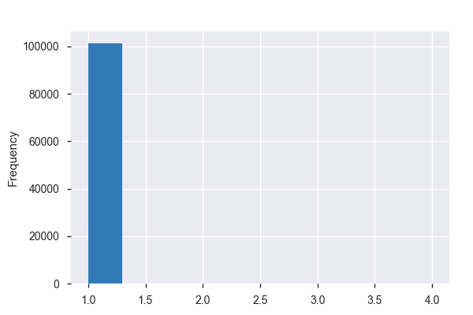

**Common Values**

| Value | Count | Frequency (%) |  |
| --- | --- | --- | --- |
| 1.0 | 101226 | 99.9% |  |
| 2.0 | 56 | 0.1% |  |
| 4.0 | 1 | 0.0% |  |
| 3.0 | 1 | 0.0% |  |

**Extreme Values**

Minimum 5 values

| Value | Count | Frequency (%) |  |
| --- | --- | --- | --- |
| 1.0 | 101226 | 99.9% |  |
| 2.0 | 56 | 0.1% |  |
| 3.0 | 1 | 0.0% |  |
| 4.0 | 1 | 0.0% |  |

Maximum 5 values

| Value | Count | Frequency (%) |  |
| --- | --- | --- | --- |
| 1.0 | 101226 | 99.9% |  |
| 2.0 | 56 | 0.1% |  |
| 3.0 | 1 | 0.0% |  |
| 4.0 | 1 | 0.0% |  |

Clase de empleado  
Categorical

| Distinct count | 36 |
| --- | --- |
| Unique (%) | 0.0% |
| Missing (%) | 0.0% |
| Missing (n) | 0 |

| EMPLEADO PARTICULAR | 52009 |
| --- | --- |
| INDEPENDIENTE | 22571 |
| ESTUDIANTE | 7656 |
| Other values (33) | 19048 |

Toggle details

| Value | Count | Frequency (%) |  |
| --- | --- | --- | --- |
| EMPLEADO PARTICULAR | 52009 | 51.3% |  |
| INDEPENDIENTE | 22571 | 22.3% |  |
| ESTUDIANTE | 7656 | 7.6% |  |
| COMERCIANTE | 4739 | 4.7% |  |
| AMA DE CASA | 4475 | 4.4% |  |
| DESEMPLEADO | 1931 | 1.9% |  |
| PENSIONADO | 1610 | 1.6% |  |
| NO REPORTA | 1601 | 1.6% |  |
| EMPLEADO PUBLICO | 1564 | 1.5% |  |
| EMPLEADO POLICIAL | 844 | 0.8% |  |
| Other values (26) | 2284 | 2.3% |  |

Clase de sitio  
Categorical

| Distinct count | 321 |
| --- | --- |
| Unique (%) | 0.3% |
| Missing (%) | 0.0% |
| Missing (n) | 0 |

| VIAS PUBLICAS | 65947 |
| --- | --- |
| CASAS DE HABITACION | 3311 |
| LOCAL COMERCIAL | 2012 |
| Other values (318) | 30014 |

Toggle details

| Value | Count | Frequency (%) |  |
| --- | --- | --- | --- |
| VIAS PUBLICAS | 65947 | 65.1% |  |
| CASAS DE HABITACION | 3311 | 3.3% |  |
| LOCAL COMERCIAL | 2012 | 2.0% |  |
| PARQUEADERO | 1769 | 1.7% |  |
| FRENTE A RESIDENCIAS - VIA PUBLICA | 1629 | 1.6% |  |
| INTERIOR VEHICULO PARTICULAR | 1523 | 1.5% |  |
| INTERIOR VEHICULO SERVICIO PUBLICO | 1458 | 1.4% |  |
| CAJERO AUTOMATICO | 1348 | 1.3% |  |
| OFICINAS | 1329 | 1.3% |  |
| DENTRO DE LA VIVIENDA | 1327 | 1.3% |  |
| Other values (311) | 19631 | 19.4% |  |

Código DANE  
Numeric

| Distinct count | 864 |
| --- | --- |
| Unique (%) | 0.9% |
| Missing (%) | 0.0% |
| Missing (n) | 0 |
| Infinite (%) | 0.0% |
| Infinite (n) | 0 |

| Mean | 34186000 |
| --- | --- |
| Minimum | 5001000 |
| Maximum | 99624000 |
| Zeros (%) | 0.0% |

Toggle details

**Statistics**

Quantile statistics

| Minimum | 5001000 |
| --- | --- |
| 5-th percentile | 5001000 |
| Q1 | 11001000 |
| Median | 17174000 |
| Q3 | 68001000 |
| 95-th percentile | 76111000 |
| Maximum | 99624000 |
| Range | 94623000 |
| Interquartile range | 57000000 |

Descriptive statistics

| Standard deviation | 28265000 |
| --- | --- |
| Coef of variation | 0.82679 |
| Kurtosis | -1.5077 |
| Mean | 34186000 |
| MAD | 26526000 |
| Skewness | 0.47284 |
| Sum | 3462500000000 |
| Variance | 798900000000000 |
| Memory size | 791.4 KiB |

**Histogram**

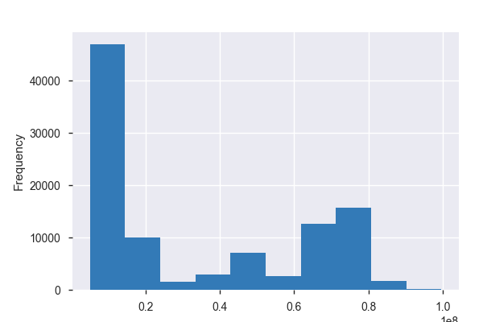

**Common Values**

| Value | Count | Frequency (%) |  |
| --- | --- | --- | --- |
| 11001000.0 | 27506 | 27.2% |  |
| 76001000.0 | 8646 | 8.5% |  |
| 5001000.0 | 7830 | 7.7% |  |
| 8001000.0 | 4693 | 4.6% |  |
| 68001000.0 | 3169 | 3.1% |  |
| 50001000.0 | 2787 | 2.8% |  |
| 73001000.0 | 2314 | 2.3% |  |
| 41001000.0 | 1962 | 1.9% |  |
| 52001000.0 | 1898 | 1.9% |  |
| 66001000.0 | 1678 | 1.7% |  |
| Other values (854) | 38801 | 38.3% |  |

**Extreme Values**

Minimum 5 values

| Value | Count | Frequency (%) |  |
| --- | --- | --- | --- |
| 5001000.0 | 7830 | 7.7% |  |
| 5002000.0 | 16 | 0.0% |  |
| 5021000.0 | 9 | 0.0% |  |
| 5030000.0 | 17 | 0.0% |  |
| 5031000.0 | 32 | 0.0% |  |

Maximum 5 values

| Value | Count | Frequency (%) |  |
| --- | --- | --- | --- |
| 95001000.0 | 41 | 0.0% |  |
| 95025000.0 | 1 | 0.0% |  |
| 97001000.0 | 13 | 0.0% |  |
| 99001000.0 | 14 | 0.0% |  |
| 99624000.0 | 2 | 0.0% |  |

Departamento  
Categorical

| Distinct count | 32 |
| --- | --- |
| Unique (%) | 0.0% |
| Missing (%) | 0.0% |
| Missing (n) | 0 |

| CUNDINAMARCA | 28523 |
| --- | --- |
| ANTIOQUIA | 12447 |
| VALLE | 12443 |
| Other values (29) | 47871 |

Toggle details

| Value | Count | Frequency (%) |  |
| --- | --- | --- | --- |
| CUNDINAMARCA | 28523 | 28.2% |  |
| ANTIOQUIA | 12447 | 12.3% |  |
| VALLE | 12443 | 12.3% |  |
| SANTANDER | 6478 | 6.4% |  |
| ATLÁNTICO | 5572 | 5.5% |  |
| TOLIMA | 3285 | 3.2% |  |
| META | 3256 | 3.2% |  |
| HUILA | 2922 | 2.9% |  |
| NARIÑO | 2439 | 2.4% |  |
| RISARALDA | 2283 | 2.3% |  |
| Other values (22) | 21636 | 21.4% |  |

Día  
Categorical

| Distinct count | 7 |
| --- | --- |
| Unique (%) | 0.0% |
| Missing (%) | 0.0% |
| Missing (n) | 0 |

| Viernes | 15722 |
| --- | --- |
| Miércoles | 15677 |
| Jueves | 15453 |
| Other values (4) | 54432 |

Toggle details

| Value | Count | Frequency (%) |  |
| --- | --- | --- | --- |
| Viernes | 15722 | 15.5% |  |
| Miércoles | 15677 | 15.5% |  |
| Jueves | 15453 | 15.3% |  |
| Sábado | 14906 | 14.7% |  |
| Martes | 14861 | 14.7% |  |
| Lunes | 13515 | 13.3% |  |
| Domingo | 11150 | 11.0% |  |

Edad  
Categorical

| Distinct count | 96 |
| --- | --- |
| Unique (%) | 0.1% |
| Missing (%) | 0.0% |
| Missing (n) | 0 |

| 30 | 3563 |
| --- | --- |
| 26 | 3402 |
| 27 | 3384 |
| Other values (93) | 90935 |

Toggle details

| Value | Count | Frequency (%) |  |
| --- | --- | --- | --- |
| 30 | 3563 | 3.5% |  |
| 26 | 3402 | 3.4% |  |
| 27 | 3384 | 3.3% |  |
| 28 | 3316 | 3.3% |  |
| 35 | 3302 | 3.3% |  |
| 25 | 3298 | 3.3% |  |
| 24 | 3194 | 3.2% |  |
| 29 | 3177 | 3.1% |  |
| 34 | 3027 | 3.0% |  |
| 32 | 2995 | 3.0% |  |
| Other values (86) | 68626 | 67.8% |  |

Escolaridad  
Categorical

| Distinct count | 7 |
| --- | --- |
| Unique (%) | 0.0% |
| Missing (%) | 0.0% |
| Missing (n) | 0 |

| SECUNDARIA | 65586 |
| --- | --- |
| SUPERIOR | 19722 |
| PRIMARIA | 7730 |
| Other values (4) | 8246 |

Toggle details

| Value | Count | Frequency (%) |  |
| --- | --- | --- | --- |
| SECUNDARIA | 65586 | 64.8% |  |
| SUPERIOR | 19722 | 19.5% |  |
| PRIMARIA | 7730 | 7.6% |  |
| TECNICO | 6418 | 6.3% |  |
| TECNOLOGO | 1120 | 1.1% |  |
| NO REPORTADO | 520 | 0.5% |  |
| ANALFABETA | 188 | 0.2% |  |

Estado civil  
Categorical

| Distinct count | 7 |
| --- | --- |
| Unique (%) | 0.0% |
| Missing (%) | 0.0% |
| Missing (n) | 0 |

| SOLTERO | 49119 |
| --- | --- |
| UNION LIBRE | 26058 |
| CASADO | 21701 |
| Other values (4) | 4406 |

Toggle details

| Value | Count | Frequency (%) |  |
| --- | --- | --- | --- |
| SOLTERO | 49119 | 48.5% |  |
| UNION LIBRE | 26058 | 25.7% |  |
| CASADO | 21701 | 21.4% |  |
| DIVORCIADO | 1698 | 1.7% |  |
| VIUDO | 1220 | 1.2% |  |
| SEPARADO | 1040 | 1.0% |  |
| NO REPORTADO | 448 | 0.4% |  |

Fecha  
Date

| Distinct count | 365 |
| --- | --- |
| Unique (%) | 0.4% |
| Missing (%) | 0.0% |
| Missing (n) | 0 |
| Infinite (%) | 0.0% |
| Infinite (n) | 0 |

| Minimum | 2015-01-01 00:00:00 |
| --- | --- |
| Maximum | 2015-12-31 00:00:00 |

Toggle details

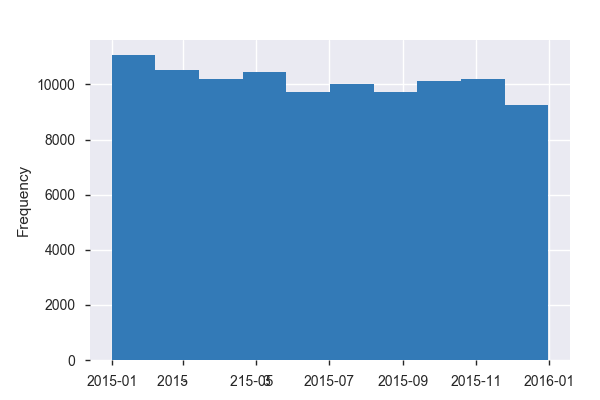

Hora  
Date

| Distinct count | 1322 |
| --- | --- |
| Unique (%) | 1.3% |
| Missing (%) | 0.0% |
| Missing (n) | 0 |
| Infinite (%) | 0.0% |
| Infinite (n) | 0 |

| Minimum | 2017-10-08 00:00:00 |
| --- | --- |
| Maximum | 2017-10-08 23:59:00 |

Toggle details

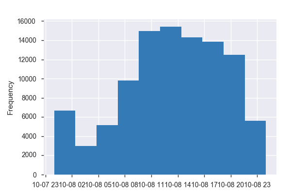

Municipio  
Categorical

| Distinct count | 814 |
| --- | --- |
| Unique (%) | 0.8% |
| Missing (%) | 0.0% |
| Missing (n) | 0 |

| BOGOTÁ D.C. (CT) | 27506 |
| --- | --- |
| CALI (CT) | 8646 |
| MEDELLÍN (CT) | 7830 |
| Other values (811) | 57302 |

Toggle details

| Value | Count | Frequency (%) |  |
| --- | --- | --- | --- |
| BOGOTÁ D.C. (CT) | 27506 | 27.2% |  |
| CALI (CT) | 8646 | 8.5% |  |
| MEDELLÍN (CT) | 7830 | 7.7% |  |
| BARRANQUILLA (CT) | 4693 | 4.6% |  |
| BUCARAMANGA (CT) | 3169 | 3.1% |  |
| VILLAVICENCIO (CT) | 2787 | 2.8% |  |
| IBAGUÉ (CT) | 2314 | 2.3% |  |
| NEIVA (CT) | 1962 | 1.9% |  |
| PASTO (CT) | 1898 | 1.9% |  |
| PEREIRA (CT) | 1678 | 1.7% |  |
| Other values (804) | 38801 | 38.3% |  |

Móvil Agresor  
Categorical

| Distinct count | 11 |
| --- | --- |
| Unique (%) | 0.0% |
| Missing (%) | 0.0% |
| Missing (n) | 0 |

| A PIE | 77109 |
| --- | --- |
| PASAJERO MOTOCICLETA | 11627 |
| CONDUCTOR MOTOCICLETA | 5143 |
| Other values (8) | 7405 |

Toggle details

| Value | Count | Frequency (%) |  |
| --- | --- | --- | --- |
| A PIE | 77109 | 76.1% |  |
| PASAJERO MOTOCICLETA | 11627 | 11.5% |  |
| CONDUCTOR MOTOCICLETA | 5143 | 5.1% |  |
| PASAJERO BUS | 2444 | 2.4% |  |
| VEHICULO | 1645 | 1.6% |  |
| BICICLETA | 1252 | 1.2% |  |
| PASAJERO TAXI | 805 | 0.8% |  |
| CONDUCTOR TAXI | 703 | 0.7% |  |
| NO REPORTADO | 281 | 0.3% |  |
| PASAJERO METRO | 235 | 0.2% |  |

Móvil Victima  
Categorical

| Distinct count | 11 |
| --- | --- |
| Unique (%) | 0.0% |
| Missing (%) | 0.0% |
| Missing (n) | 0 |

| A PIE | 81197 |
| --- | --- |
| VEHICULO | 8651 |
| CONDUCTOR MOTOCICLETA | 3649 |
| Other values (8) | 7787 |

Toggle details

| Value | Count | Frequency (%) |  |
| --- | --- | --- | --- |
| A PIE | 81197 | 80.2% |  |
| VEHICULO | 8651 | 8.5% |  |
| CONDUCTOR MOTOCICLETA | 3649 | 3.6% |  |
| PASAJERO BUS | 2352 | 2.3% |  |
| BICICLETA | 1798 | 1.8% |  |
| CONDUCTOR TAXI | 863 | 0.9% |  |
| PASAJERO TAXI | 846 | 0.8% |  |
| PASAJERO MOTOCICLETA | 818 | 0.8% |  |
| CONDUCTOR BUS | 494 | 0.5% |  |
| NO REPORTADO | 383 | 0.4% |  |

País de nacimiento  
Categorical

| Distinct count | 70 |
| --- | --- |
| Unique (%) | 0.1% |
| Missing (%) | 0.0% |
| Missing (n) | 0 |

| COLOMBIA | 98365 |
| --- | --- |
| NO REPORTADO | 2187 |
| ESTADOS UNIDOS | 97 |
| Other values (67) | 635 |

Toggle details

| Value | Count | Frequency (%) |  |
| --- | --- | --- | --- |
| COLOMBIA | 98365 | 97.1% |  |
| NO REPORTADO | 2187 | 2.2% |  |
| ESTADOS UNIDOS | 97 | 0.1% |  |
| VENEZUELA | 87 | 0.1% |  |
| ECUADOR | 56 | 0.1% |  |
| ESPAÑA | 55 | 0.1% |  |
| BRASIL | 41 | 0.0% |  |
| FRANCIA | 37 | 0.0% |  |
| ARGENTINA | 36 | 0.0% |  |
| AUSTRALIA | 33 | 0.0% |  |
| Other values (60) | 290 | 0.3% |  |

Profesión  
Categorical

| Distinct count | 101 |
| --- | --- |
| Unique (%) | 0.1% |
| Missing (%) | 0.0% |
| Missing (n) | 0 |

| NO REPORTADO | 89754 |
| --- | --- |
| ADMINISTRADOR DE EMPRESAS | 1512 |
| ABOGADO | 953 |
| Other values (98) | 9065 |

Toggle details

| Value | Count | Frequency (%) |  |
| --- | --- | --- | --- |
| NO REPORTADO | 89754 | 88.6% |  |
| ADMINISTRADOR DE EMPRESAS | 1512 | 1.5% |  |
| ABOGADO | 953 | 0.9% |  |
| LICENCIADO | 818 | 0.8% |  |
| INGENIERO | 774 | 0.8% |  |
| POLICIA | 640 | 0.6% |  |
| TECNICO EN SISTEMAS | 467 | 0.5% |  |
| TECNICO EMPRESARIAL | 457 | 0.5% |  |
| INGENIERO DE SISTEMAS | 378 | 0.4% |  |
| MEDICO | 346 | 0.3% |  |
| Other values (91) | 5185 | 5.1% |  |

Sexo  
Categorical

| Distinct count | 3 |
| --- | --- |
| Unique (%) | 0.0% |
| Missing (%) | 0.0% |
| Missing (n) | 0 |

| MASCULINO | 60780 |
| --- | --- |
| FEMENINO | 40499 |
| NO REPORTADO | 5 |

Toggle details

| Value | Count | Frequency (%) |  |
| --- | --- | --- | --- |
| MASCULINO | 60780 | 60.0% |  |
| FEMENINO | 40499 | 40.0% |  |
| NO REPORTADO | 5 | 0.0% |  |

Zona  
Categorical

| Distinct count | 2 |
| --- | --- |
| Unique (%) | 0.0% |
| Missing (%) | 0.0% |
| Missing (n) | 0 |

| URBANA | 96438 |
| --- | --- |
| RURAL | 4846 |

Toggle details

| Value | Count | Frequency (%) |  |
| --- | --- | --- | --- |
| URBANA | 96438 | 95.2% |  |
| RURAL | 4846 | 4.8% |  |

index  
Categorical, Unique

| First 3 values |
| --- |
| 25695 |
| 82587 |
| 46151 |

| Last 3 values |
| --- |
| 21080 |
| 96057 |
| 71283 |

Toggle details

First 10 values

| Value | Count | Frequency (%) |  |
| --- | --- | --- | --- |
| 0 | 1 | 0.0% |  |
| 1 | 1 | 0.0% |  |
| 10 | 1 | 0.0% |  |
| 100 | 1 | 0.0% |  |
| 1000 | 1 | 0.0% |  |

Last 10 values

| Value | Count | Frequency (%) |  |
| --- | --- | --- | --- |
| 99995 | 1 | 0.0% |  |
| 99996 | 1 | 0.0% |  |
| 99997 | 1 | 0.0% |  |
| 99998 | 1 | 0.0% |  |
| 99999 | 1 | 0.0% |  |

Sample

|  | Fecha | Departamento | Municipio | Día | Hora | Barrio | Zona | Clase de sitio | Arma empleada | Móvil Agresor | Móvil Victima | Edad | Sexo | Estado civil | País de nacimiento | Clase de empleado | Profesión | Escolaridad | Código DANE | Cantidad |
| --- | --- | --- | --- | --- | --- | --- | --- | --- | --- | --- | --- | --- | --- | --- | --- | --- | --- | --- | --- | --- |
| 0 | 2015-01-01 | AMAZONAS | LETICIA (CT) | Jueves | 2017-10-08 18:10:00 | UNION | URBANA | VIAS PUBLICAS | ARMA BLANCA | A PIE | A PIE | 26 | FEMENINO | UNION LIBRE | COLOMBIA | EMPLEADO PARTICULAR | NO REPORTADO | SECUNDARIA | 91001000.0 | 1.0 |
| 1 | 2015-01-01 | ANTIOQUIA | BELLO | Jueves | 2017-10-08 00:00:00 | LA GABRIELA | URBANA | BARES, CANTINAS Y SIMILARES | SIN EMPLEO DE ARMAS | A PIE | A PIE | 46 | FEMENINO | SOLTERO | NO REPORTADO | INDEPENDIENTE | NO REPORTADO | SECUNDARIA | 5088000.0 | 1.0 |
| 2 | 2015-01-01 | ANTIOQUIA | CAUCASIA | Jueves | 2017-10-08 15:20:00 | LAS MALVINAS | URBANA | CASAS DE HABITACION | SIN EMPLEO DE ARMAS | A PIE | A PIE | 29 | MASCULINO | SOLTERO | COLOMBIA | EMPLEADO EJERCITO | NO REPORTADO | SECUNDARIA | 5154000.0 | 1.0 |
| 3 | 2015-01-01 | ANTIOQUIA | GUARNE | Jueves | 2017-10-08 19:00:00 | AUTOPISTA MEDELLIN-BOGOTA | RURAL | RESTAURANTES | SIN EMPLEO DE ARMAS | A PIE | A PIE | 39 | MASCULINO | CASADO | COLOMBIA | COMERCIANTE | NO REPORTADO | SECUNDARIA | 5318000.0 | 1.0 |
| 4 | 2015-01-01 | ANTIOQUIA | ITAGUI | Jueves | 2017-10-08 14:00:00 | VILLA LIA | URBANA | DENTRO DE LA VIVIENDA | CONTUNDENTES | A PIE | A PIE | 27 | MASCULINO | SOLTERO | COLOMBIA | INDEPENDIENTE | NO REPORTADO | SECUNDARIA | 5360000.0 | 1.0 |

```python
pandas_profiling.ProfileReport(hp2015)
```

Overview

Dataset info

| Number of variables | 21 |
| --- | --- |
| Number of observations | 94342 |
| Total Missing (%) | 0.0% |
| Total size in memory | 15.1 MiB |
| Average record size in memory | 168.0 B |

Variables types

| Numeric | 2 |
| --- | --- |
| Categorical | 16 |
| Date | 2 |
| Text (Unique) | 1 |
| Rejected | 0 |

Warnings

- `Barrio` has a high cardinality: 10552 distinct values Warning

- `Cantidad` is highly skewed (γ1 = 38.467)

- `Clase de sitio` has a high cardinality: 196 distinct values Warning

- `Edad` has a high cardinality: 97 distinct values Warning

- `Municipio` has a high cardinality: 780 distinct values Warning

- `País de nacimiento` has a high cardinality: 54 distinct values Warning

- `Profesión` has a high cardinality: 106 distinct values Warning

Variables

Arma empleada  
Categorical

| Distinct count | 9 |
| --- | --- |
| Unique (%) | 0.0% |
| Missing (%) | 0.0% |
| Missing (n) | 0 |

| SIN EMPLEO DE ARMAS | 42298 |
| --- | --- |
| ARMA BLANCA | 18198 |
| ARMA DE FUEGO | 17393 |
| Other values (6) | 16453 |

Toggle details

| Value | Count | Frequency (%) |  |
| --- | --- | --- | --- |
| SIN EMPLEO DE ARMAS | 42298 | 44.8% |  |
| ARMA BLANCA | 18198 | 19.3% |  |
| ARMA DE FUEGO | 17393 | 18.4% |  |
| CONTUNDENTES | 14510 | 15.4% |  |
| ESCOPOLAMINA | 842 | 0.9% |  |
| CORTANTES | 547 | 0.6% |  |
| NO REPORTADO | 484 | 0.5% |  |
| PERRO | 69 | 0.1% |  |
| JERINGA | 1 | 0.0% |  |

Barrio  
Categorical

| Distinct count | 10552 |
| --- | --- |
| Unique (%) | 11.2% |
| Missing (%) | 0.0% |
| Missing (n) | 0 |

| CENTRO | 5411 |
| --- | --- |
| EL CENTRO | 1067 |
| LA CANDELARIA C-10 | 744 |
| Other values (10549) | 87120 |

Toggle details

| Value | Count | Frequency (%) |  |
| --- | --- | --- | --- |
| CENTRO | 5411 | 5.7% |  |
| EL CENTRO | 1067 | 1.1% |  |
| LA CANDELARIA C-10 | 744 | 0.8% |  |
| CHAPINERO CENTRAL E-2 | 447 | 0.5% |  |
| BARRIO CENTRO | 340 | 0.4% |  |
| SAN PEDRO E3 | 324 | 0.3% |  |
| LOS CEDRITOS E-1 | 274 | 0.3% |  |
| TEUSAQUILLO E-13 | 272 | 0.3% |  |
| SAN JOSE | 269 | 0.3% |  |
| CHAPINERO ALTO E-2 | 251 | 0.3% |  |
| Other values (10542) | 84943 | 90.0% |  |

Cantidad  
Numeric

| Distinct count | 3 |
| --- | --- |
| Unique (%) | 0.0% |
| Missing (%) | 0.0% |
| Missing (n) | 0 |
| Infinite (%) | 0.0% |
| Infinite (n) | 0 |

| Mean | 1.0007 |
| --- | --- |
| Minimum | 1 |
| Maximum | 3 |
| Zeros (%) | 0.0% |

Toggle details

**Statistics**

Quantile statistics

| Minimum | 1 |
| --- | --- |
| 5-th percentile | 1 |
| Q1 | 1 |
| Median | 1 |
| Q3 | 1 |
| 95-th percentile | 1 |
| Maximum | 3 |
| Range | 2 |
| Interquartile range | 0 |

Descriptive statistics

| Standard deviation | 0.027424 |
| --- | --- |
| Coef of variation | 0.027404 |
| Kurtosis | 1548.5 |
| Mean | 1.0007 |
| MAD | 0.0014617 |
| Skewness | 38.467 |
| Sum | 94411 |
| Variance | 0.00075205 |
| Memory size | 737.1 KiB |

**Histogram**

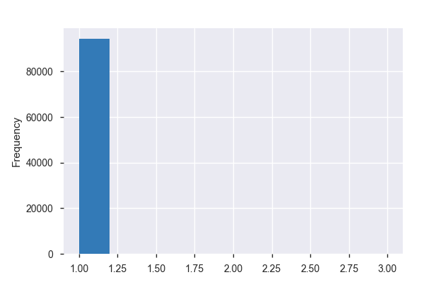

**Common Values**

| Value | Count | Frequency (%) |  |
| --- | --- | --- | --- |
| 1 | 94274 | 99.9% |  |
| 2 | 67 | 0.1% |  |
| 3 | 1 | 0.0% |  |

**Extreme Values**

Minimum 5 values

| Value | Count | Frequency (%) |  |
| --- | --- | --- | --- |
| 1 | 94274 | 99.9% |  |
| 2 | 67 | 0.1% |  |
| 3 | 1 | 0.0% |  |

Maximum 5 values

| Value | Count | Frequency (%) |  |
| --- | --- | --- | --- |
| 1 | 94274 | 99.9% |  |
| 2 | 67 | 0.1% |  |
| 3 | 1 | 0.0% |  |

Clase de empleado  
Categorical

| Distinct count | 35 |
| --- | --- |
| Unique (%) | 0.0% |
| Missing (%) | 0.0% |
| Missing (n) | 0 |

| EMPLEADO PARTICULAR | 45883 |
| --- | --- |
| INDEPENDIENTE | 22214 |
| ESTUDIANTE | 7615 |
| Other values (32) | 18630 |

Toggle details

| Value | Count | Frequency (%) |  |
| --- | --- | --- | --- |
| EMPLEADO PARTICULAR | 45883 | 48.6% |  |
| INDEPENDIENTE | 22214 | 23.5% |  |
| ESTUDIANTE | 7615 | 8.1% |  |
| COMERCIANTE | 4974 | 5.3% |  |
| AMA DE CASA | 4401 | 4.7% |  |
| DESEMPLEADO | 2235 | 2.4% |  |
| PENSIONADO | 1360 | 1.4% |  |
| EMPLEADO PUBLICO | 1329 | 1.4% |  |
| NO REPORTA | 1077 | 1.1% |  |
| EMPLEADO POLICIAL | 841 | 0.9% |  |
| Other values (25) | 2413 | 2.6% |  |

Clase de sitio  
Categorical

| Distinct count | 196 |
| --- | --- |
| Unique (%) | 0.2% |
| Missing (%) | 0.0% |
| Missing (n) | 0 |

| VIAS PUBLICAS | 61053 |
| --- | --- |
| CASAS DE HABITACION | 3365 |
| FRENTE A RESIDENCIAS NO REPORTADO VIA PUBLICA | 2278 |
| Other values (193) | 27646 |

Toggle details

| Value | Count | Frequency (%) |  |
| --- | --- | --- | --- |
| VIAS PUBLICAS | 61053 | 64.7% |  |
| CASAS DE HABITACION | 3365 | 3.6% |  |
| FRENTE A RESIDENCIAS NO REPORTADO VIA PUBLICA | 2278 | 2.4% |  |
| LOCAL COMERCIAL | 1793 | 1.9% |  |
| PARQUEADERO | 1666 | 1.8% |  |
| INTERIOR VEHICULO SERVICIO PUBLICO | 1633 | 1.7% |  |
| OFICINAS | 1512 | 1.6% |  |
| DENTRO DE LA VIVIENDA | 1329 | 1.4% |  |
| INTERIOR VEHICULO PARTICULAR | 1266 | 1.3% |  |
| SOBRE ANDEN NO REPORTADO VIA PUBLICA | 1179 | 1.2% |  |
| Other values (186) | 17268 | 18.3% |  |

Código DANE  
Numeric

| Distinct count | 826 |
| --- | --- |
| Unique (%) | 0.9% |
| Missing (%) | 0.0% |
| Missing (n) | 0 |
| Infinite (%) | 0.0% |
| Infinite (n) | 0 |

| Mean | 35395000 |
| --- | --- |
| Minimum | 5001000 |
| Maximum | 99773000 |
| Zeros (%) | 0.0% |

Toggle details

**Statistics**

Quantile statistics

| Minimum | 5001000 |
| --- | --- |
| 5-th percentile | 5001000 |
| Q1 | 11001000 |
| Median | 18001000 |
| Q3 | 68001000 |
| 95-th percentile | 76111000 |
| Maximum | 99773000 |
| Range | 94772000 |
| Interquartile range | 57000000 |

Descriptive statistics

| Standard deviation | 28247000 |
| --- | --- |
| Coef of variation | 0.79804 |
| Kurtosis | -1.5736 |
| Mean | 35395000 |
| MAD | 26639000 |
| Skewness | 0.41665 |
| Sum | 3339300000000 |
| Variance | 797880000000000 |
| Memory size | 737.1 KiB |

**Histogram**

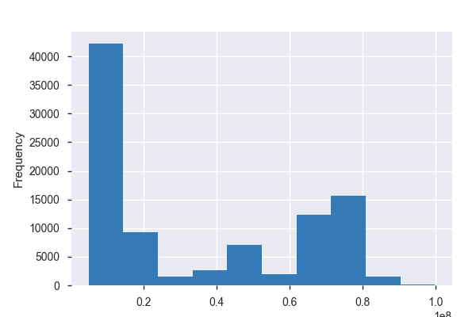

**Common Values**

| Value | Count | Frequency (%) |  |
| --- | --- | --- | --- |
| 11001000.0 | 28107 | 29.8% |  |
| 76001000.0 | 9130 | 9.7% |  |
| 5001000.0 | 4949 | 5.2% |  |
| 8001000.0 | 4437 | 4.7% |  |
| 68001000.0 | 2758 | 2.9% |  |
| 50001000.0 | 2678 | 2.8% |  |
| 73001000.0 | 1958 | 2.1% |  |
| 41001000.0 | 1839 | 1.9% |  |
| 52001000.0 | 1813 | 1.9% |  |
| 66001000.0 | 1804 | 1.9% |  |
| Other values (816) | 34869 | 37.0% |  |

**Extreme Values**

Minimum 5 values

| Value | Count | Frequency (%) |  |
| --- | --- | --- | --- |
| 5001000.0 | 4949 | 5.2% |  |
| 5002000.0 | 7 | 0.0% |  |
| 5030000.0 | 5 | 0.0% |  |
| 5031000.0 | 6 | 0.0% |  |
| 5034000.0 | 13 | 0.0% |  |

Maximum 5 values

| Value | Count | Frequency (%) |  |
| --- | --- | --- | --- |
| 95200000.0 | 3 | 0.0% |  |
| 97001000.0 | 6 | 0.0% |  |
| 97161000.0 | 2 | 0.0% |  |
| 99001000.0 | 4 | 0.0% |  |
| 99773000.0 | 1 | 0.0% |  |

Departamento  
Categorical

| Distinct count | 32 |
| --- | --- |
| Unique (%) | 0.0% |
| Missing (%) | 0.0% |
| Missing (n) | 0 |

| CUNDINAMARCA | 29175 |
| --- | --- |
| VALLE | 12845 |
| ANTIOQUIA | 7211 |
| Other values (29) | 45111 |

Toggle details

| Value | Count | Frequency (%) |  |
| --- | --- | --- | --- |
| CUNDINAMARCA | 29175 | 30.9% |  |
| VALLE | 12845 | 13.6% |  |
| ANTIOQUIA | 7211 | 7.6% |  |
| SANTANDER | 6053 | 6.4% |  |
| ATLÁNTICO | 5426 | 5.8% |  |
| META | 3119 | 3.3% |  |
| TOLIMA | 2860 | 3.0% |  |
| HUILA | 2619 | 2.8% |  |
| RISARALDA | 2507 | 2.7% |  |
| CALDAS | 2396 | 2.5% |  |
| Other values (22) | 20131 | 21.3% |  |

Día  
Categorical

| Distinct count | 7 |
| --- | --- |
| Unique (%) | 0.0% |
| Missing (%) | 0.0% |
| Missing (n) | 0 |

| Viernes | 14895 |
| --- | --- |
| Miércoles | 14639 |
| Martes | 14105 |
| Other values (4) | 50703 |

Toggle details

| Value | Count | Frequency (%) |  |
| --- | --- | --- | --- |
| Viernes | 14895 | 15.8% |  |
| Miércoles | 14639 | 15.5% |  |
| Martes | 14105 | 15.0% |  |
| Jueves | 14016 | 14.9% |  |
| Sábado | 13792 | 14.6% |  |
| Lunes | 12825 | 13.6% |  |
| Domingo | 10070 | 10.7% |  |

Edad  
Categorical

| Distinct count | 97 |
| --- | --- |
| Unique (%) | 0.1% |
| Missing (%) | 0.0% |
| Missing (n) | 0 |

| 27 | 3318 |
| --- | --- |
| 34 | 3264 |
| 25 | 3235 |
| Other values (94) | 84525 |

Toggle details

| Value | Count | Frequency (%) |  |
| --- | --- | --- | --- |
| 27 | 3318 | 3.5% |  |
| 34 | 3264 | 3.5% |  |
| 25 | 3235 | 3.4% |  |
| 24 | 3152 | 3.3% |  |
| 28 | 3082 | 3.3% |  |
| 30 | 3075 | 3.3% |  |
| 29 | 3044 | 3.2% |  |
| 32 | 3012 | 3.2% |  |
| 26 | 2963 | 3.1% |  |
| 35 | 2937 | 3.1% |  |
| Other values (87) | 63260 | 67.1% |  |

Escolaridad  
Categorical

| Distinct count | 7 |
| --- | --- |
| Unique (%) | 0.0% |
| Missing (%) | 0.0% |
| Missing (n) | 0 |

| SECUNDARIA | 59033 |
| --- | --- |
| SUPERIOR | 19849 |
| PRIMARIA | 7489 |
| Other values (4) | 7971 |

Toggle details

| Value | Count | Frequency (%) |  |
| --- | --- | --- | --- |
| SECUNDARIA | 59033 | 62.6% |  |
| SUPERIOR | 19849 | 21.0% |  |
| PRIMARIA | 7489 | 7.9% |  |
| TECNICO | 6451 | 6.8% |  |
| TECNOLOGO | 925 | 1.0% |  |
| NO REPORTADO | 351 | 0.4% |  |
| ANALFABETA | 244 | 0.3% |  |

Estado civil  
Categorical

| Distinct count | 7 |
| --- | --- |
| Unique (%) | 0.0% |
| Missing (%) | 0.0% |
| Missing (n) | 0 |

| SOLTERO | 45174 |
| --- | --- |
| UNION LIBRE | 23970 |
| CASADO | 21332 |
| Other values (4) | 3866 |

Toggle details

| Value | Count | Frequency (%) |  |
| --- | --- | --- | --- |
| SOLTERO | 45174 | 47.9% |  |
| UNION LIBRE | 23970 | 25.4% |  |
| CASADO | 21332 | 22.6% |  |
| DIVORCIADO | 1528 | 1.6% |  |
| VIUDO | 1124 | 1.2% |  |
| SEPARADO | 921 | 1.0% |  |
| NO REPORTADO | 293 | 0.3% |  |

Fecha  
Date

| Distinct count | 365 |
| --- | --- |
| Unique (%) | 0.4% |
| Missing (%) | 0.0% |
| Missing (n) | 0 |
| Infinite (%) | 0.0% |
| Infinite (n) | 0 |

| Minimum | 2014-01-01 00:00:00 |
| --- | --- |
| Maximum | 2014-12-31 00:00:00 |

Toggle details

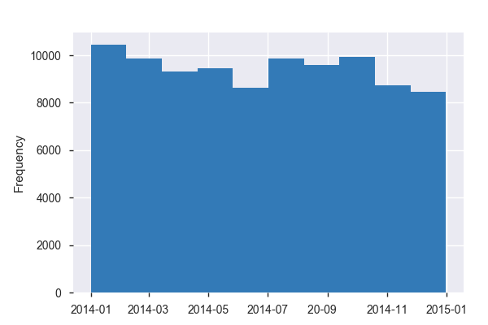

Hora  
Date

| Distinct count | 1318 |
| --- | --- |
| Unique (%) | 1.4% |
| Missing (%) | 0.0% |
| Missing (n) | 0 |
| Infinite (%) | 0.0% |
| Infinite (n) | 0 |

| Minimum | 2017-10-08 00:00:00 |
| --- | --- |
| Maximum | 2017-10-08 23:59:00 |

Toggle details

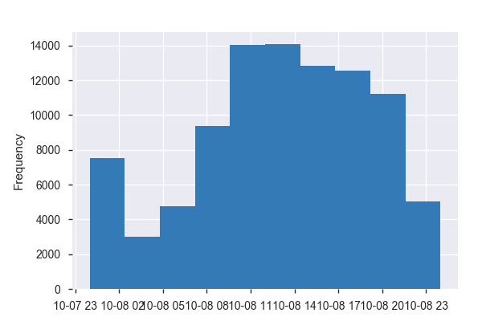

Municipio  
Categorical

| Distinct count | 780 |
| --- | --- |
| Unique (%) | 0.8% |
| Missing (%) | 0.0% |
| Missing (n) | 0 |

| BOGOTÁ D.C. (CT) | 28107 |
| --- | --- |
| CALI (CT) | 9130 |
| MEDELLÍN (CT) | 4949 |
| Other values (777) | 52156 |

Toggle details

| Value | Count | Frequency (%) |  |
| --- | --- | --- | --- |
| BOGOTÁ D.C. (CT) | 28107 | 29.8% |  |
| CALI (CT) | 9130 | 9.7% |  |
| MEDELLÍN (CT) | 4949 | 5.2% |  |
| BARRANQUILLA (CT) | 4437 | 4.7% |  |
| BUCARAMANGA (CT) | 2758 | 2.9% |  |
| VILLAVICENCIO (CT) | 2678 | 2.8% |  |
| IBAGUÉ (CT) | 1958 | 2.1% |  |
| NEIVA (CT) | 1839 | 1.9% |  |
| PASTO (CT) | 1813 | 1.9% |  |
| PEREIRA (CT) | 1804 | 1.9% |  |
| Other values (770) | 34869 | 37.0% |  |

Móvil Agresor  
Categorical

| Distinct count | 11 |
| --- | --- |
| Unique (%) | 0.0% |
| Missing (%) | 0.0% |
| Missing (n) | 0 |

| A PIE | 73679 |
| --- | --- |
| PASAJERO MOTOCICLETA | 9593 |
| CONDUCTOR MOTOCICLETA | 4231 |
| Other values (8) | 6839 |

Toggle details

| Value | Count | Frequency (%) |  |
| --- | --- | --- | --- |
| A PIE | 73679 | 78.1% |  |
| PASAJERO MOTOCICLETA | 9593 | 10.2% |  |
| CONDUCTOR MOTOCICLETA | 4231 | 4.5% |  |
| PASAJERO BUS | 2159 | 2.3% |  |
| VEHICULO | 1571 | 1.7% |  |
| BICICLETA | 1140 | 1.2% |  |
| PASAJERO TAXI | 761 | 0.8% |  |
| CONDUCTOR TAXI | 671 | 0.7% |  |
| NO REPORTADO | 482 | 0.5% |  |
| PASAJERO METRO | 44 | 0.0% |  |

Móvil Victima  
Categorical

| Distinct count | 11 |
| --- | --- |
| Unique (%) | 0.0% |
| Missing (%) | 0.0% |
| Missing (n) | 0 |

| A PIE | 76353 |
| --- | --- |
| VEHICULO | 8161 |
| CONDUCTOR MOTOCICLETA | 2948 |
| Other values (8) | 6880 |

Toggle details

| Value | Count | Frequency (%) |  |
| --- | --- | --- | --- |
| A PIE | 76353 | 80.9% |  |
| VEHICULO | 8161 | 8.7% |  |
| CONDUCTOR MOTOCICLETA | 2948 | 3.1% |  |
| PASAJERO BUS | 2029 | 2.2% |  |
| BICICLETA | 1614 | 1.7% |  |
| CONDUCTOR TAXI | 807 | 0.9% |  |
| PASAJERO MOTOCICLETA | 779 | 0.8% |  |
| PASAJERO TAXI | 773 | 0.8% |  |
| NO REPORTADO | 672 | 0.7% |  |
| CONDUCTOR BUS | 170 | 0.2% |  |

País de nacimiento  
Categorical

| Distinct count | 54 |
| --- | --- |
| Unique (%) | 0.1% |
| Missing (%) | 0.0% |
| Missing (n) | 0 |

| COLOMBIA | 92054 |
| --- | --- |
| NO REPORTADO | 1832 |
| ESTADOS UNIDOS | 89 |
| Other values (51) | 367 |

Toggle details

| Value | Count | Frequency (%) |  |
| --- | --- | --- | --- |
| COLOMBIA | 92054 | 97.6% |  |
| NO REPORTADO | 1832 | 1.9% |  |
| ESTADOS UNIDOS | 89 | 0.1% |  |
| ESPAÑA | 35 | 0.0% |  |
| VENEZUELA | 33 | 0.0% |  |
| BRASIL | 30 | 0.0% |  |
| MEXICO | 28 | 0.0% |  |
| ECUADOR | 22 | 0.0% |  |
| FRANCIA | 22 | 0.0% |  |
| ARGENTINA | 18 | 0.0% |  |
| Other values (44) | 179 | 0.2% |  |

Profesión  
Categorical

| Distinct count | 106 |
| --- | --- |
| Unique (%) | 0.1% |
| Missing (%) | 0.0% |
| Missing (n) | 0 |

| NO REPORTADO | 82973 |
| --- | --- |
| ADMINISTRADOR DE EMPRESAS | 1480 |
| ABOGADO | 966 |
| Other values (103) | 8923 |

Toggle details

| Value | Count | Frequency (%) |  |
| --- | --- | --- | --- |
| NO REPORTADO | 82973 | 87.9% |  |
| ADMINISTRADOR DE EMPRESAS | 1480 | 1.6% |  |
| ABOGADO | 966 | 1.0% |  |
| LICENCIADO | 792 | 0.8% |  |
| INGENIERO | 762 | 0.8% |  |
| POLICIA | 711 | 0.8% |  |
| TECNICO EMPRESARIAL | 388 | 0.4% |  |
| INGENIERO DE SISTEMAS | 385 | 0.4% |  |
| TECNICO EN SISTEMAS | 374 | 0.4% |  |
| MEDICO | 367 | 0.4% |  |
| Other values (96) | 5144 | 5.5% |  |

Sexo  
Categorical

| Distinct count | 3 |
| --- | --- |
| Unique (%) | 0.0% |
| Missing (%) | 0.0% |
| Missing (n) | 0 |

| MASCULINO | 57289 |
| --- | --- |
| FEMENINO | 37051 |
| NO REPORTADO | 2 |

Toggle details

| Value | Count | Frequency (%) |  |
| --- | --- | --- | --- |
| MASCULINO | 57289 | 60.7% |  |
| FEMENINO | 37051 | 39.3% |  |
| NO REPORTADO | 2 | 0.0% |  |

Zona  
Categorical

| Distinct count | 3 |
| --- | --- |
| Unique (%) | 0.0% |
| Missing (%) | 0.0% |
| Missing (n) | 0 |

| URBANA | 90139 |
| --- | --- |
| RURAL | 4200 |
| OTRAS | 3 |

Toggle details

| Value | Count | Frequency (%) |  |
| --- | --- | --- | --- |
| URBANA | 90139 | 95.5% |  |
| RURAL | 4200 | 4.5% |  |
| OTRAS | 3 | 0.0% |  |

index  
Categorical, Unique

| First 3 values |
| --- |
| 90446 |
| 29705 |
| 29397 |

| Last 3 values |
| --- |
| 92810 |
| 28954 |
| 30822 |

Toggle details

First 10 values

| Value | Count | Frequency (%) |  |
| --- | --- | --- | --- |
| 0 | 1 | 0.0% |  |
| 1 | 1 | 0.0% |  |
| 10 | 1 | 0.0% |  |
| 100 | 1 | 0.0% |  |
| 1000 | 1 | 0.0% |  |

Last 10 values

| Value | Count | Frequency (%) |  |
| --- | --- | --- | --- |
| 9995 | 1 | 0.0% |  |
| 9996 | 1 | 0.0% |  |
| 9997 | 1 | 0.0% |  |
| 9998 | 1 | 0.0% |  |
| 9999 | 1 | 0.0% |  |

Sample

|  | Fecha | Departamento | Municipio | Día | Hora | Barrio | Zona | Clase de sitio | Arma empleada | Móvil Agresor | Móvil Victima | Edad | Sexo | Estado civil | País de nacimiento | Clase de empleado | Profesión | Escolaridad | Código DANE | Cantidad |
| --- | --- | --- | --- | --- | --- | --- | --- | --- | --- | --- | --- | --- | --- | --- | --- | --- | --- | --- | --- | --- |
| 0 | 2014-01-01 | AMAZONAS | LETICIA (CT) | Miércoles | 2017-10-08 09:00:00 | KILOMETROS | RURAL | INSTALACIONES DE LA POLICIA | CONTUNDENTES | A PIE | A PIE | 25 | MASCULINO | SOLTERO | COLOMBIA | EMPLEADO POLICIAL | POLICIA | TECNICO | 91001000.0 | 1 |
| 1 | 2014-01-01 | ANTIOQUIA | ITAGUI | Miércoles | 2017-10-08 06:00:00 | EL ROSARIO | URBANA | DENTRO DE LA VIVIENDA | SIN EMPLEO DE ARMAS | A PIE | A PIE | 37 | FEMENINO | CASADO | COLOMBIA | AMA DE CASA | NO REPORTADO | SECUNDARIA | 5360000.0 | 1 |
| 2 | 2014-01-01 | ANTIOQUIA | ITAGUI | Miércoles | 2017-10-08 07:20:00 | SANTA MARIA # 2 | URBANA | PUENTE | ARMA DE FUEGO | A PIE | A PIE | 29 | MASCULINO | UNION LIBRE | COLOMBIA | EMPLEADO PARTICULAR | NO REPORTADO | SECUNDARIA | 5360000.0 | 1 |
| 3 | 2014-01-01 | ANTIOQUIA | ITAGUI | Miércoles | 2017-10-08 15:30:00 | LOS NARANJOS | URBANA | VIAS PUBLICAS | ARMA DE FUEGO | A PIE | A PIE | 34 | FEMENINO | CASADO | COLOMBIA | EMPLEADO PARTICULAR | CONTADOR | SUPERIOR | 5360000.0 | 1 |
| 4 | 2014-01-01 | ANTIOQUIA | ITAGUI | Miércoles | 2017-10-08 15:59:00 | CENTRO | URBANA | VIAS PUBLICAS | CONTUNDENTES | A PIE | A PIE | 29 | FEMENINO | SOLTERO | COLOMBIA | EMPLEADO PARTICULAR | NO REPORTADO | SUPERIOR | 5360000.0 | 1 |

```python
pandas_profiling.ProfileReport(hp2014)
```

Overview

Dataset info

| Number of variables | 4 |
| --- | --- |
| Number of observations | 1308 |
| Total Missing (%) | 0.0% |
| Total size in memory | 41.0 KiB |
| Average record size in memory | 32.1 B |

Variables types

| Numeric | 3 |
| --- | --- |
| Categorical | 0 |
| Date | 1 |
| Text (Unique) | 0 |
| Rejected | 0 |

Warnings

Variables

Cantidad  
Numeric

| Distinct count | 143 |
| --- | --- |
| Unique (%) | 10.9% |
| Missing (%) | 0.0% |
| Missing (n) | 0 |
| Infinite (%) | 0.0% |
| Infinite (n) | 0 |

| Mean | 89.009 |
| --- | --- |
| Minimum | 16 |
| Maximum | 192 |
| Zeros (%) | 0.0% |

Toggle details

**Statistics**

Quantile statistics

| Minimum | 16 |
| --- | --- |
| 5-th percentile | 46 |
| Q1 | 69 |
| Median | 87 |
| Q3 | 105 |
| 95-th percentile | 140.65 |
| Maximum | 192 |
| Range | 176 |
| Interquartile range | 36 |

Descriptive statistics

| Standard deviation | 28.539 |
| --- | --- |
| Coef of variation | 0.32063 |
| Kurtosis | 0.10629 |
| Mean | 89.009 |
| MAD | 22.479 |
| Skewness | 0.4239 |
| Sum | 116424 |
| Variance | 814.45 |
| Memory size | 10.3 KiB |

**Histogram**

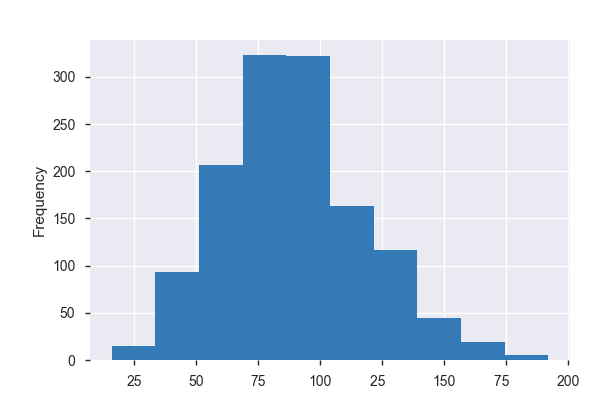

**Common Values**

| Value | Count | Frequency (%) |  |
| --- | --- | --- | --- |
| 77 | 28 | 2.1% |  |
| 88 | 25 | 1.9% |  |
| 87 | 24 | 1.8% |  |
| 85 | 23 | 1.8% |  |
| 69 | 22 | 1.7% |  |
| 103 | 21 | 1.6% |  |
| 82 | 21 | 1.6% |  |
| 94 | 21 | 1.6% |  |
| 90 | 21 | 1.6% |  |
| 73 | 20 | 1.5% |  |
| Other values (133) | 1082 | 82.7% |  |

**Extreme Values**

Minimum 5 values

| Value | Count | Frequency (%) |  |
| --- | --- | --- | --- |
| 16 | 1 | 0.1% |  |
| 23 | 1 | 0.1% |  |
| 24 | 2 | 0.2% |  |
| 25 | 2 | 0.2% |  |
| 27 | 1 | 0.1% |  |

Maximum 5 values

| Value | Count | Frequency (%) |  |
| --- | --- | --- | --- |
| 175 | 1 | 0.1% |  |
| 177 | 1 | 0.1% |  |
| 179 | 1 | 0.1% |  |
| 181 | 1 | 0.1% |  |
| 192 | 1 | 0.1% |  |

Fecha  
Date

| Distinct count | 1308 |
| --- | --- |
| Unique (%) | 100.0% |
| Missing (%) | 0.0% |
| Missing (n) | 0 |
| Infinite (%) | 0.0% |
| Infinite (n) | 0 |

| Minimum | 2014-01-01 00:00:00 |
| --- | --- |
| Maximum | 2017-07-31 00:00:00 |

Toggle details

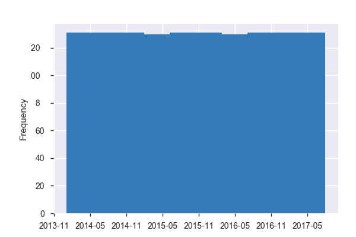

ciclo  
Numeric

| Distinct count | 1308 |
| --- | --- |
| Unique (%) | 100.0% |
| Missing (%) | 0.0% |
| Missing (n) | 0 |
| Infinite (%) | 0.0% |
| Infinite (n) | 0 |

| Mean | 1.0505e-12 |
| --- | --- |
| Minimum | -71.552 |
| Maximum | 66.114 |
| Zeros (%) | 0.0% |

Toggle details

**Statistics**

Quantile statistics

| Minimum | -71.552 |
| --- | --- |
| 5-th percentile | -38.068 |
| Q1 | -12.214 |
| Median | 2.4802 |
| Q3 | 13.472 |
| 95-th percentile | 31.382 |
| Maximum | 66.114 |
| Range | 137.67 |
| Interquartile range | 25.686 |

Descriptive statistics

| Standard deviation | 20.754 |
| --- | --- |
| Coef of variation | 19755000000000 |
| Kurtosis | 0.033724 |
| Mean | 1.0505e-12 |
| MAD | 16.297 |
| Skewness | -0.35872 |
| Sum | 1.3741e-09 |
| Variance | 430.71 |
| Memory size | 10.3 KiB |

**Histogram**

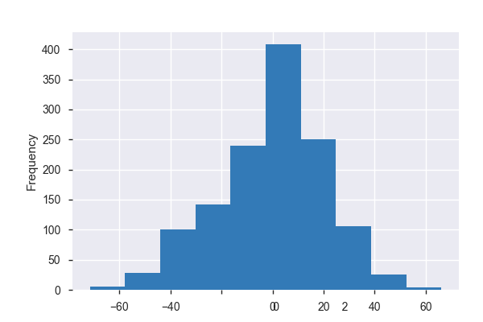

**Common Values**

| Value | Count | Frequency (%) |  |
| --- | --- | --- | --- |
| 6.28889337022 | 1 | 0.1% |  |
| 9.05967429756 | 1 | 0.1% |  |
| 26.2105336634 | 1 | 0.1% |  |
| 3.62071500263 | 1 | 0.1% |  |
| 8.36726377377 | 1 | 0.1% |  |
| -7.3613187794 | 1 | 0.1% |  |
| 28.1228382109 | 1 | 0.1% |  |
| 0.594759151266 | 1 | 0.1% |  |
| 26.8412028742 | 1 | 0.1% |  |
| 21.9687095638 | 1 | 0.1% |  |
| Other values (1298) | 1298 | 99.2% |  |

**Extreme Values**

Minimum 5 values

| Value | Count | Frequency (%) |  |
| --- | --- | --- | --- |
| -71.5516613619 | 1 | 0.1% |  |
| -66.2486623738 | 1 | 0.1% |  |
| -63.9706422684 | 1 | 0.1% |  |
| -59.2263379742 | 1 | 0.1% |  |
| -58.1582045878 | 1 | 0.1% |  |

Maximum 5 values

| Value | Count | Frequency (%) |  |
| --- | --- | --- | --- |
| 50.3777070782 | 1 | 0.1% |  |
| 54.0377379922 | 1 | 0.1% |  |
| 55.2153350239 | 1 | 0.1% |  |
| 61.9867129411 | 1 | 0.1% |  |
| 66.1136731536 | 1 | 0.1% |  |

tend  
Numeric

| Distinct count | 1308 |
| --- | --- |
| Unique (%) | 100.0% |
| Missing (%) | 0.0% |
| Missing (n) | 0 |
| Infinite (%) | 0.0% |
| Infinite (n) | 0 |

| Mean | 89.009 |
| --- | --- |
| Minimum | 53.818 |
| Maximum | 140 |
| Zeros (%) | 0.0% |

Toggle details

**Statistics**

Quantile statistics

| Minimum | 53.818 |
| --- | --- |
| 5-th percentile | 67.726 |
| Q1 | 74.89 |
| Median | 85.217 |
| Q3 | 98.659 |
| 95-th percentile | 132.4 |
| Maximum | 140 |
| Range | 86.178 |
| Interquartile range | 23.77 |

Descriptive statistics

| Standard deviation | 18.669 |
| --- | --- |
| Coef of variation | 0.20974 |
| Kurtosis | 0.41981 |
| Mean | 89.009 |
| MAD | 14.608 |
| Skewness | 0.96763 |
| Sum | 116420 |
| Variance | 348.52 |
| Memory size | 10.3 KiB |

**Histogram**

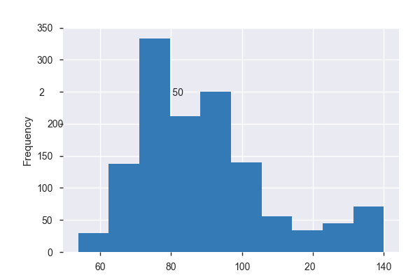

**Common Values**

| Value | Count | Frequency (%) |  |
| --- | --- | --- | --- |
| 90.0970861629 | 1 | 0.1% |  |
| 96.6889931862 | 1 | 0.1% |  |
| 90.0308305861 | 1 | 0.1% |  |
| 96.302441782 | 1 | 0.1% |  |
| 81.8137498631 | 1 | 0.1% |  |
| 83.1571307168 | 1 | 0.1% |  |
| 80.5043025958 | 1 | 0.1% |  |
| 96.4642761591 | 1 | 0.1% |  |
| 73.1225148399 | 1 | 0.1% |  |
| 98.843092482 | 1 | 0.1% |  |
| Other values (1298) | 1298 | 99.2% |  |

**Extreme Values**

Minimum 5 values

| Value | Count | Frequency (%) |  |
| --- | --- | --- | --- |
| 53.8180194754 | 1 | 0.1% |  |
| 53.9234751357 | 1 | 0.1% |  |
| 53.9768706414 | 1 | 0.1% |  |
| 54.2959022534 | 1 | 0.1% |  |
| 54.3781027405 | 1 | 0.1% |  |

Maximum 5 values

| Value | Count | Frequency (%) |  |
| --- | --- | --- | --- |
| 139.757710127 | 1 | 0.1% |  |
| 139.873195574 | 1 | 0.1% |  |
| 139.933215926 | 1 | 0.1% |  |
| 139.970642268 | 1 | 0.1% |  |
| 139.996484045 | 1 | 0.1% |  |

Sample

| Fecha | Cantidad | tend | ciclo |
| --- | --- | --- | --- |
| 2014-01-01 | 50 | 74.205386 | -24.205386 |
| 2014-01-02 | 89 | 75.745754 | 13.254246 |
| 2014-01-03 | 62 | 77.270994 | -15.270994 |
| 2014-01-04 | 82 | 78.774260 | 3.225740 |
| 2014-01-05 | 64 | 80.239165 | -16.239165 |

```python
pandas_profiling.ProfileReport(hp_2)
```

```python
#pandas_profiling.ProfileReport(hp)
```

```python
hp.head()
```

|  | Fecha | Departamento | Municipio | Día | Hora | Barrio | Zona | Clase de sitio | Arma empleada | Móvil Agresor | Móvil Victima | Edad | Sexo | Estado civil | País de nacimiento | Clase de empleado | Profesión | Escolaridad | Código DANE | Cantidad |
| --- | --- | --- | --- | --- | --- | --- | --- | --- | --- | --- | --- | --- | --- | --- | --- | --- | --- | --- | --- | --- |
| 55 | 2014-01-01 | CUNDINAMARCA | BOGOTÁ D.C. (CT) | Miércoles | 2017-10-08 00:00:00 | CIUDAD KENNEDY CENTRAL E-8 | URBANA | VIAS PUBLICAS | SIN EMPLEO DE ARMAS | A PIE | A PIE | 50 | MASCULINO | SOLTERO | COLOMBIA | EMPLEADO PARTICULAR | NO REPORTADO | SECUNDARIA | 11001000.0 | 1.0 |
| 56 | 2014-01-01 | CUNDINAMARCA | BOGOTÁ D.C. (CT) | Miércoles | 2017-10-08 01:30:00 | GUADUAL E-9 | URBANA | CASA EN CONJUNTO CERRADO | CONTUNDENTES | A PIE | A PIE | 26 | MASCULINO | SOLTERO | COLOMBIA | INDEPENDIENTE | NO REPORTADO | SECUNDARIA | 11001000.0 | 1.0 |
| 57 | 2014-01-01 | CUNDINAMARCA | BOGOTÁ D.C. (CT) | Miércoles | 2017-10-08 02:00:00 | SANTA CATALINA E-8 | URBANA | CASAS DE HABITACION | CONTUNDENTES | A PIE | A PIE | 65 | MASCULINO | CASADO | COLOMBIA | EMPLEADO PARTICULAR | NO REPORTADO | PRIMARIA | 11001000.0 | 1.0 |
| 58 | 2014-01-01 | CUNDINAMARCA | BOGOTÁ D.C. (CT) | Miércoles | 2017-10-08 02:45:00 | SAN CARLOS PREDIO SAN JOSÉ E-6 | URBANA | VIAS PUBLICAS | ARMA DE FUEGO | PASAJERO TAXI | CONDUCTOR TAXI | 22 | MASCULINO | SOLTERO | COLOMBIA | INDEPENDIENTE | NO REPORTADO | SECUNDARIA | 11001000.0 | 1.0 |
| 59 | 2014-01-01 | CUNDINAMARCA | BOGOTÁ D.C. (CT) | Miércoles | 2017-10-08 03:30:00 | MARIA PAZ E-8 | URBANA | VIAS PUBLICAS | ARMA BLANCA | A PIE | A PIE | 55 | FEMENINO | SOLTERO | COLOMBIA | AMA DE CASA | NO REPORTADA | SECUNDARIA | 11001000.0 | 1.0 |

```python
hp_2.head()
```

| Fecha | Cantidad | tend | ciclo |
| --- | --- | --- | --- |
| 2014-01-01 | 50 | 74.205386 | -24.205386 |
| 2014-01-02 | 89 | 75.745754 | 13.254246 |
| 2014-01-03 | 62 | 77.270994 | -15.270994 |
| 2014-01-04 | 82 | 78.774260 | 3.225740 |
| 2014-01-05 | 64 | 80.239165 | -16.239165 |

### Exportando datos

```python
hp.to_csv('hurtoPersonasConsolidado.csv')
```

```python
hp_2.to_csv('hurtoPersonasFrecuencia.csv')
```